# [EM1413] - Health Data Science

Passi Analysis

Step by Passi** • Angeletti Giacomo – 888843 • Crapanzano Edoardo – 889685 • Dumitru Vlad Adrian – 883731 • Zago Francesco – 889002

2025-05-18 **© 2025 Giacomo Angeletti, Edoardo Crapanzano, Vlad Adrian Dumitru, Francesco Zago. All rights reserved.

# 1 Introduction

In this study, we aim to examine the cardiovascular risk, the presence of chronic disease, and psycho-physical health in the Italian population using data from the **PASSI surveillance system**, which has been operational nationwide since 2008. Each year, the PASSI survey collects self-reported information on lifestyle habits, risk factors, and health conditions via telephone interviews with a representative sample of residents aged 18 to 69. Thanks to the breadth and temporal continuity of these data, we can estimate the prevalence of hypertension, diabetes, overweight/obesity, smoking, and physical inactivity, as well as measure psychological well-being indicators such as anxiety, depression, and overall quality of life.  
It is important to emphasize that PASSI data are cross-sectional, not panel: each year’s sample is newly drawn, and the same individuals are not followed over time. This design allows us to accurately describe aggregate distributions and trends year by year, but id does not permit reconstruction of individual trajectories of risk evolution or health-status transitions. The cross-sectional nature of the data therefore limits causal inferences at the individual level, while ensuring a precise and representative snapshot of adult health conditions in Italy for each survey year.  
In our study we have decided to analyse the years of 2009 and 2019, in order to be able to observe changes over the course of ten years.  
The topics covered will be the following:  
• **SOCIOECONOMIC VARIABLES RELATED TO CHRONIC DISEASES**;  
• **CARDIOVASCULAR RISK IN RELATION TO THE QUANTITY OF CIGARETTES SMOKED AND ALCOHOL CONSUMPTION**;  
• **HYPERTENSION CONDITIONS RELATED TO PHYSICAL ACTIVITY**;  
• **PHYSICAL HEALTH IN RELATION TO MENTAL WELL-BEING**.

## 1.1 Uploading and Data Cleaning

```r
passi_cleaned = read.csv("passi_cleaned")
```

The packages used to create the codes are the following:

```r
library(tidyverse)      # Collection of data science packages
library(dplyr)          # Data manipulation with verbs
library(lme4)           # Fit mixed-effects models
library(MASS)           # Stats functions and datasets
library(ggplot2)        # Create elegant data visualizations
library(tidyr)          # Tidy and reshape data
library(sf)             # Handle spatial vector data
library(broom.mixed)    # Tidy mixed model outputs
library(epitools)       # Epidemiological analysis tools
library(scales)         # Scale functions for visualization
library(AER)            # Overdispersion test
library(lmtest)         # Tests for linear regression models
library(Matrix)         # Sparse and dense matrix operations
library(car)            # Companion to applied regression
library(gridExtra)      # Arrange multiple grid-based plots
```

Since the regions within the dataset were named using codes, we modified each number to correspond to the correct name of the region.

```r
regions_name = c(
  "10" = "Piemonte",
  "20" = "Valle D'Aosta",
  "30" = "Lombardia",
  "41" = "Alto Adige",
  "42" = "Trentino",
  "50" = "Veneto",
  "60"= "Friuli Venezia Giulia",
  "70" = "Liguria",
  "80" = "Emilia-Romagna",
  "90" = "Toscana",
  "100" = "Umbria",
  "110" = "Marche",
  "120" = "Lazio",
  "130" = "Abruzzo",
  "140" = "Molise",
  "150" = "Campania",
  "160" = "Puglia",
  "170" = "Basilicata",
  "180" = "Calabria",
  "190" = "Sicilia",
  "200" = "Sardegna")

# Then we modify the old `regione` with the new values
passi_cleaned$regione = regions_name[as.character(passi_cleaned$regione)]
```

From the dataset `passi_cleaned`, for both years of interest (2009 and 2019), we have selected only the variables necessary for our analysis, in order to make it easier to read and modify the dataset.

```r
dataset_provvisorio = passi_cleaned %>% filter(anno == 2009 | anno == 2019) %>%
  dplyr::select(anno,regione,asl,sesso_intervistato,claeta3,comune_intervistato,lettera_asl,
                claeta3,s01_salute,s01_salute_fis,s01_salute_psic,s01_abit_attiv,s01_diabete,
                s01_insuff_renale,s01_asma_bronchiale,s01_bronchite,s01_ictus,s01_ima,
                s01_altre_malattie_cuore,s01_tumori,s01_malattie_croniche,s01_artrosi,
                s01_vaccin,s01_vaccin_ultima,s02_lavoro,s02_lavoro_attiv,s02_tlib_attiv_inte,
                s02_tlib_attiv_inte_gg,s02_tlib_attiv_inte_min,s02_attiv_moder,
                s02_attiv_moder_gg,s02_attiv_moder_min,s02_attiv_30_gg_quanto,
                s02_sanit_att_chiesto,s03_fumo_chiesto,s03_fumo,s03_fumo_att,
                s03_fumo_quanto,s03_smesso_tent,s03_fumo_cons,s03_sugg_op_san,
                s03_influenza_consiglio,s03_smesso_quando,s03_sugg_op_san,
                s03_influenza_consiglio,s03_smesso_come,s03_fumava_quanto,
                s03_fumo_pubblico,s03_lav_amb_chiusi,s03_fumo_lavoro,s04_peso_cons,
                s04_peso_dieta,s04_peso_giud,s04_consu_frutta,s05_alcool_gg,
                s05_alcool_quanto,s05_alcool_quando,s05_alcool_quando_pasti,
                s05_alcool_quanto_piu,s05_alcool_quanto_piu,s05_alcool_guida,
                s05_alcool_guida_volte,s05_alcool_passegg,s05_alcool_passegg_volte,
                s05_alcool_chiesto,s05_alcool_sugg_san,s05_alcool_sugg_fam,
                s05_alcool_sugg_altro,s05_alcool_sugg_no,s05_alcool_sugg_non_so,
                s05_alcool_passegg,s05_alcool_passegg_volte,s05_alcool_chiesto,
                s07_press_mis,s07_press_quando,s07_press_alta,s07_sugg_sale_press,
                s07_sugg_att_fis_press,s07_sugg_peso_press,s07_press_farm,
                s07_colest_mis,s07_colest_quando,s07_med_colest_alto,s07_sugg_carne_col,
                s07_sugg_att_fis_col,s07_sugg_peso_col,s07_sugg_frutta_col,s07_colest_farm,
                s07_eta,s07_calc_risc,s12_poco_inter_gg,s12_giu_morale_gg,s12_aiuto_sanit,
                s12_aiuto_fiducia,s12_aiuto_no,s12_aiuto_non_ric,s14_stato_civ,s14_con_nes,
                s14_con_coni,s14_con_bamb,s14_con_giov_ad,s14_con_anz,s14_cittadin, s14_cittadin_ita,
                s14_cittadin_stran,s14_tempo_in_italia,s14_tit_stud,s14_disp_econ,s14_altez,s14_peso,cardiovasc)
```

Then we extracted a **representative sample (20%)** from the dataset `dataset_provvisorio`, maintaining the representativeness of some categories:  
• **Year**;  
• **ASL**;  
• **Sex**;  
• **Age classes (18-34, 35-49, 50-69)**.

```r
set.seed(123)
dataset_definitivo = dataset_provvisorio %>%
  group_by(anno, asl, sesso_intervistato, claeta3) %>%
  slice_sample(prop = 0.2) %>%
  ungroup()
```

# 2 Socioeconomic Variables related to Chronic Diseases

In this section, a subset of the full dataset was created in order to focus the analysis on a selection of relevant socioeconomic variables. These include: height, weight, gender, age group, income level, education level, citizenship, year, region, and local health authority (ASL).  
The analytical approach followed a stepwise structure. First, a preliminary exploration was conducted for each variable to assess its distribution and potential association with the risk of chronic diseases. Based on this exploration, each variable was evaluated before inclusion in the models.  
The first main objective was to model the risk of having at least one chronic disease using **logistic regression**. This was done separately for the years 2009 and 2019 to investigate potential differences over time.  
Subsequently, to account for territorial effects, a **Generalized Linear Mixed Model (GLMM)** was fitted, incorporating either regions or local health authorities (ASL) as random effects. Model comparisons were carried out to determine which random effect structure provided the best fit.  
Finally, the outcome variable was redefined to represent the number of chronic diseases reported by each individual. In this case, the suitability of **count data models** was examined, and both Poisson and Negative Binomial regressions were tested to identify the most appropriate specification.

```r
# The variable s14_cittadin was used for the year 2019, whereas s14_cittadin_ita was used for 2009
dataset_definitivo$cittadinanza = ifelse(dataset_definitivo$anno == 2019,
  dataset_definitivo$s14_cittadin, dataset_definitivo$s14_cittadin_ita)

dtpa = dataset_definitivo %>% dplyr::select(s01_diabete, s01_insuff_renale, s01_bronchite, s01_ima, s01_tumori, cittadinanza, s14_cittadin_stran, s14_tit_stud, s14_disp_econ, s14_altez, s14_peso, sesso_intervistato, claeta3, anno, regione, asl)

dtpa$s01_diabete = as.factor(dtpa$s01_diabete)
dtpa$s01_insuff_renale = as.factor(dtpa$s01_insuff_renale)
dtpa$s01_bronchite = as.factor(dtpa$s01_bronchite)
dtpa$s01_ima = as.factor(dtpa$s01_ima)
dtpa$s01_tumori = as.factor(dtpa$s01_tumori)

dtpa$cittadinanza = as.factor(dtpa$cittadinanza)
dtpa$s14_tit_stud = as.factor(dtpa$s14_tit_stud)
dtpa$s14_disp_econ = as.factor(dtpa$s14_disp_econ)
dtpa$sesso_intervistato = as.factor(dtpa$sesso_intervistato)
dtpa$claeta3 = as.factor(dtpa$claeta3)
dtpa$regione = as.factor(dtpa$regione)
dtpa$anno = as.factor(dtpa$anno)

dtpa = dtpa[complete.cases(dtpa[c("s14_disp_econ",
                                  "s14_tit_stud","cittadinanza")]), ]
dtpa = dtpa[dtpa$cittadinanza != "", ]
dtpa$cittadinanza = droplevels(dtpa$cittadinanza) # Removes the levels that are no longer present

dtpa$claeta3= ifelse(dtpa$claeta3 == 1, '18-34',
                                   ifelse(dtpa$claeta3 == 2, '35-49',
                                          ifelse(dtpa$claeta3 == 3, '50-69', NA)))
```

## 2.1 Logistic Regression analysis

As previously mentioned, this chapter presents a logistic regression analysis. It begins by focusing on key variables established in the medical literature, namely **BMI**, **age**, and **gender**, before exploring additional variables of interest.
Our response variable was constructed as follows:
$$\text{malattiecroniche}_i =
\begin{cases}
1 & \text{if the subject has at least one chronic disease} \\
0 & \text{otherwise}
\end{cases}$$

```r
dtpa$malattiecroniche = ifelse(dtpa$s01_diabete == "t" | dtpa$s01_insuff_renale == "t" |
  dtpa$s01_bronchite == "t"  | dtpa$s01_ima == "t"  | dtpa$s01_tumori == "t" , 1, 0)
dtpa$malattiecroniche = as.factor(dtpa$malattiecroniche)
```

**BMI**
Body Mass Index (BMI) is a widely used indicator to classify individuals based on their body weight relative to height. BMI is commonly used to assess whether a person is underweight, normal weight, overweight, or obese, which are categories associated with varying health risks. It is calculated as the ratio of weight in kilograms to the square of height in meters:
$$\text{BMI} = \frac{\text{weight (kg)}}{\text{height (m)}^2}$$

```r
dtpa$BMI = dtpa$s14_peso / ((dtpa$s14_altez/100)^2)
dtpa = dtpa %>% filter(BMI <= 80) # Avoiding meaningless observations (height=1)
```

A histogram was created to visualize the distribution of the BMI variable:

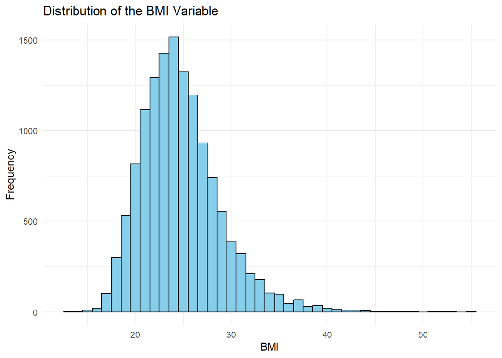

```r
ggplot(dtpa, aes(x = BMI)) +
  geom_histogram(binwidth = 1, fill = "skyblue", color = "black") +
  labs(title = "Distribution of the BMI Variable", x = "BMI", y = "Frequency")+
  theme_minimal()
```

To assess whether BMI differs between individuals with and without chronic diseases, Shapiro-Wilk tests were performed separately for the two groups. At least one group did not follow a normal distribution. Additionally, the Levene’s Test indicated that the variances between groups were not equal.  
Therefore, a Wilcoxon rank-sum test was used instead of a t-test.

```r
shapiro.test(dtpa$BMI[dtpa$malattiecroniche == 1])  # Not normal
```

```
##
##  Shapiro-Wilk normality test
##
## data:  dtpa$BMI[dtpa$malattiecroniche == 1]
## W = 0.96189, p-value < 2.2e-16
```

```r
leveneTest(BMI ~ malattiecroniche, data = dtpa)     # Different variances
```

```
## Levene's Test for Homogeneity of Variance (center = median)
##          Df F value    Pr(>F)
## group     1   95.45 < 2.2e-16 ***
##       13457
## ---
## Signif. codes:  0 '***' 0.001 '**' 0.01 '*' 0.05 '.' 0.1 ' ' 1
```

```r
# Use Wilcox
wilcox.test(BMI ~ malattiecroniche, data = dtpa)
```

```
##
##  Wilcoxon rank sum test with continuity correction
##
## data:  BMI by malattiecroniche
## W = 9346831, p-value < 2.2e-16
## alternative hypothesis: true location shift is not equal to 0
```

Since the null hypothesis was rejected, we have evidence to suggest that there is a significant association between BMI and the presence of chronic diseases.  
A boxplot was created to compare the distribution of BMI values between individuals with and without chronic diseases, highlighting differences in median, spread, and potential outliers.  
Moreover, density plots with transparency were overlaid to visualize and compare the distribution shapes of BMI for the two groups (with and without chronic diseases). Different colors represent each group for better distinction.

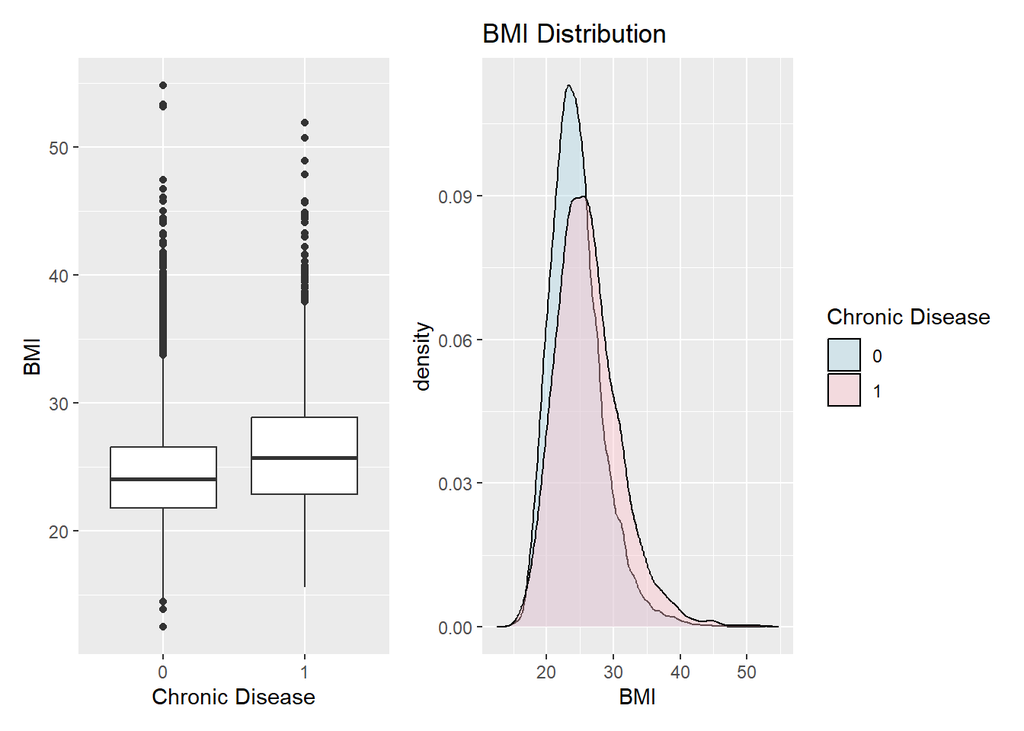

```r
# Boxplot
p1 = ggplot(dtpa, aes(x = malattiecroniche, y = BMI)) +  geom_boxplot()  +
  labs(x = "Chronic Disease")

# Overlapping distributions
p2 = ggplot(dtpa, aes(x = BMI, fill = as.factor(malattiecroniche))) +
  geom_density(alpha = 0.4) +
  scale_fill_manual(values = c("lightblue", "pink")) +
  labs(title = "BMI Distribution", x = "BMI", fill = "Chronic Disease")

library(patchwork)
p1 + p2
```

We can see that people with at least one chronic disease have, on average, a significantly higher BMI than those without any chronic diseases.  
**Sex**  
To explore the relationship between chronic diseases and sex, we first create a contingency table of disease status by sex. Then, we calculate the conditional probabilities of having a chronic disease given each sex group, which provides a clearer understanding of the distribution of chronic diseases within males and females.

```r
table(dtpa$malattiecroniche, dtpa$sesso_intervistato)
```

```
##
##        F    M
##   0 5804 5545
##   1 1063 1047
```

```r
prop.table(table(dtpa$malattiecroniche, dtpa$sesso_intervistato), margin = 2)
```

```
##
##             F         M
##   0 0.8452017 0.8411711
##   1 0.1547983 0.1588289
```

```r
# For this study, it makes more sense to ask: given that the sex is female, what is the proportion of those with and without chronic diseases? This represents the conditional probability P(disease|sex=F).
```

A Chi-squared test of independence is performed to assess whether there is a statistically significant association between chronic disease status and sex.

```r
chisq.test(table(dtpa$malattiecroniche, dtpa$sesso_intervistato))
```

```
##
##  Pearson's Chi-squared test with Yates' continuity correction
##
## data:  table(dtpa$malattiecroniche, dtpa$sesso_intervistato)
## X-squared = 0.3834, df = 1, p-value = 0.5358
```

There is no statistically significant evidence to suggest that the presence of chronic diseases depends on sex.  
The following plot provides a visual representation of this relationship:

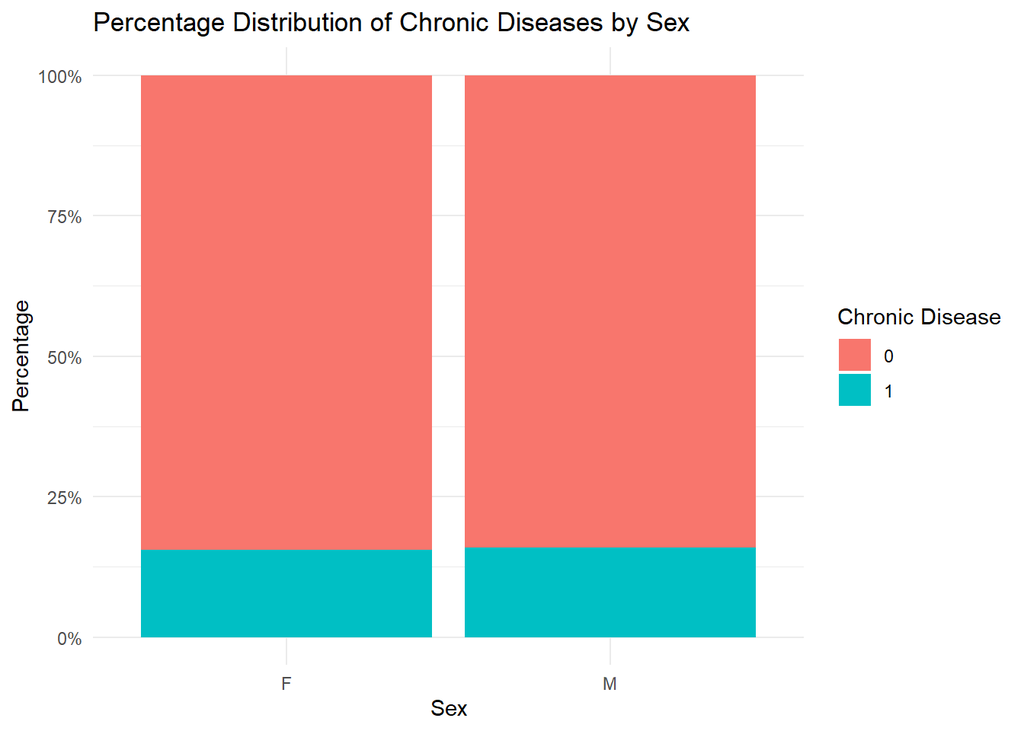

```r
ggplot(dtpa, aes(x = sesso_intervistato, fill = malattiecroniche)) +
  geom_bar(position = "fill") +
  scale_y_continuous(labels = scales::percent) +
  labs(fill = "Chronic Disease", x = "Sex", y = "Percentage", ,
  title = "Percentage Distribution of Chronic Diseases by Sex") +
  theme_minimal()
```

**Age Group**  
Age group is theoretically expected to influence the risk of chronic diseases, as supported by existing literature. Generally, older individuals have a higher likelihood of developing chronic conditions compared to younger age groups.  
The same steps used for the sex variable are applied to test this.

```r
table(dtpa$malattiecroniche, dtpa$claeta3)
```

```
##
##     18-34 35-49 50-69
##   0  3441  4061  3847
##   1   192   456  1462
```

```r
prop.table(table(dtpa$malattiecroniche, dtpa$claeta3), margin = 2)
```

```
##
##          18-34      35-49      50-69
##   0 0.94715111 0.89904804 0.72461857
##   1 0.05284889 0.10095196 0.27538143
```

```r
chisq.test(table(dtpa$malattiecroniche, dtpa$claeta3))
```

```
##
##  Pearson's Chi-squared test
##
## data:  table(dtpa$malattiecroniche, dtpa$claeta3)
## X-squared = 968.26, df = 2, p-value < 2.2e-16
```

The chi-squared test reveals a statistically significant association between age group (categorized into three levels) and the presence of at least one chronic disease (p < 0.001). The proportion of individuals with chronic diseases increases clearly with age, from 5,3% in the youngest group to 27,5% in the oldest group. This suggests that age is strongly associated with the risk of developing chronic conditions, as expected.

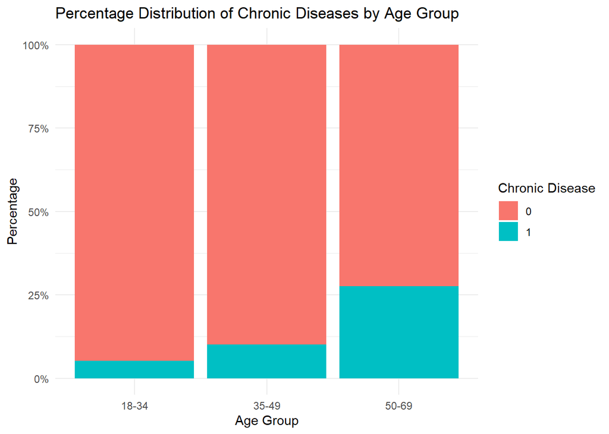

```r
ggplot(dtpa, aes(x = claeta3, fill = malattiecroniche)) +
  geom_bar(position = "fill") +
  scale_y_continuous(labels = scales::percent) +
  labs(fill = "Chronic Disease", x = "Age Group", y = "Percentage",
       title = "Percentage Distribution of Chronic Diseases by Age Group") +
  theme_minimal()
```

### 2.1.1 Basic Models

Throughout the logistic regression analysis, a separate model is estimated for each year (2009 and 2019). The aim is not only to assess the impact of various predictors on the likelihood of having at least one chronic disease, but also to identify the best-fitting model for each year, taking into account that the underlying mechanisms may have changed over time.  
In this sense, the model is tailored to the data structure of each specific year, in order to better capture the context of that period.  
Any differences observed in the coefficients across years may suggest changes in the role of certain variables; however, such differences are not formally tested for statistical significance.

```r
mod_log_1_2009 = glm(malattiecroniche ~ BMI + claeta3 + sesso_intervistato,
                      data = dtpa, subset = anno == 2009, family = binomial)

summary(mod_log_1_2009)
```

```
##
## Call:
## glm(formula = malattiecroniche ~ BMI + claeta3 + sesso_intervistato,
##     family = binomial, data = dtpa, subset = anno == 2009)
##
## Coefficients:
##                      Estimate Std. Error z value Pr(>|z|)
## (Intercept)         -3.794410   0.195659 -19.393  < 2e-16 ***
## BMI                  0.053351   0.007511   7.103 1.22e-12 ***
## claeta335-49         0.516059   0.104482   4.939 7.84e-07 ***
## claeta350-69         1.698562   0.096171  17.662  < 2e-16 ***
## sesso_intervistatoM  0.008240   0.063262   0.130    0.896
## ---
## Signif. codes:  0 '***' 0.001 '**' 0.01 '*' 0.05 '.' 0.1 ' ' 1
##
## (Dispersion parameter for binomial family taken to be 1)
##
##     Null deviance: 7166.6  on 7391  degrees of freedom
## Residual deviance: 6492.9  on 7387  degrees of freedom
## AIC: 6502.9
##
## Number of Fisher Scoring iterations: 5
```

```r
mod_log_1_2019 = glm(malattiecroniche ~ BMI + claeta3 + sesso_intervistato,
                      data = dtpa, subset = anno == 2019, family = binomial)

summary(mod_log_1_2019)
```

```
##
## Call:
## glm(formula = malattiecroniche ~ BMI + claeta3 + sesso_intervistato,
##     family = binomial, data = dtpa, subset = anno == 2019)
##
## Coefficients:
##                      Estimate Std. Error z value Pr(>|z|)
## (Intercept)         -4.946142   0.267851 -18.466  < 2e-16 ***
## BMI                  0.059099   0.009102   6.493 8.44e-11 ***
## claeta335-49         0.902631   0.181101   4.984 6.22e-07 ***
## claeta350-69         2.143145   0.165319  12.964  < 2e-16 ***
## sesso_intervistatoM -0.105914   0.083710  -1.265    0.206
## ---
## Signif. codes:  0 '***' 0.001 '**' 0.01 '*' 0.05 '.' 0.1 ' ' 1
##
## (Dispersion parameter for binomial family taken to be 1)
##
##     Null deviance: 4392  on 6066  degrees of freedom
## Residual deviance: 3940  on 6062  degrees of freedom
## AIC: 3950
##
## Number of Fisher Scoring iterations: 6
```

For both years, the coefficients associated with BMI and age groups are statistically significant, suggesting that these variables consistently play an important role in predicting the likelihood of having at least one chronic disease.  
To facilitate visualization and comparison, a table was created to display the differences between the estimated coefficients.

```r
# Comparison
coef_2009 = summary(mod_log_1_2009)$coefficients
coef_2019 = summary(mod_log_1_2019)$coefficients

confronto = data.frame(
  "Estimate_2009" = coef_2009[, "Estimate"],
  "SE_2009" = coef_2009[, "Std. Error"],
  "Estimate_2019" = coef_2019[, "Estimate"],
  "SE_2019" = coef_2019[, "Std. Error"]
)
confronto$Differenza = confronto$Estimate_2019 - confronto$Estimate_2009
round(confronto, 3)
```

```
##                     Estimate_2009 SE_2009 Estimate_2019 SE_2019 Differenza
## (Intercept)                -3.794   0.196        -4.946   0.268     -1.152
## BMI                         0.053   0.008         0.059   0.009      0.006
## claeta335-49                0.516   0.104         0.903   0.181      0.387
## claeta350-69                1.699   0.096         2.143   0.165      0.445
## sesso_intervistatoM         0.008   0.063        -0.106   0.084     -0.114
```

The most notable differences are found in the coefficients for the older age groups. In both cases, the increase from 2009 to 2019 suggests that, all else being equal, the association between age and the likelihood of having at least one chronic disease has become stronger over time. However, these differences are not statistically tested, and should therefore be interpreted as descriptive insights rather than as conclusive evidence of change.  
Although the intercept represents the log-odds when all predictors are equal to zero, which is not a meaningful scenario in practice (e.g., BMI = 0), the difference between the intercepts for 2009 and 2019 may still carry some interpretive value. It could reflect systemic changes in the population context over time that are not fully explained by the variables included in the model.  
**Basic Models with interactions**  
To better investigate the role of sex, interaction terms were included in the basic models.  
It is possible that sex does not have a significant average effect, but still plays a role by influencing the relationship between other variables and chronic disease. For example, the effect of age or BMI on the risk of chronic conditions may differ between men and women.

```r
# To address multicollinearity issues, the BMI variable is centered
dtpa$BMI_c = as.numeric(scale(dtpa$BMI, center = TRUE, scale = FALSE))

mod_log_1b_2009 = glm(malattiecroniche ~ BMI_c*sesso_intervistato + claeta3*sesso_intervistato, family = binomial, subset = anno == 2009, data = dtpa)

summary(mod_log_1b_2009)
```

```
##
## Call:
## glm(formula = malattiecroniche ~ BMI_c * sesso_intervistato +
##     claeta3 * sesso_intervistato, family = binomial, data = dtpa,
##     subset = anno == 2009)
##
## Coefficients:
##                                   Estimate Std. Error z value Pr(>|z|)
## (Intercept)                      -2.364622   0.118782 -19.907  < 2e-16 ***
## BMI_c                             0.050930   0.009553   5.331 9.76e-08 ***
## sesso_intervistatoM              -0.213321   0.171145  -1.246 0.212604
## claeta335-49                      0.508414   0.144200   3.526 0.000422 ***
## claeta350-69                      1.519735   0.134076  11.335  < 2e-16 ***
## BMI_c:sesso_intervistatoM         0.010468   0.015487   0.676 0.499079
## sesso_intervistatoM:claeta335-49  0.004465   0.209421   0.021 0.982989
## sesso_intervistatoM:claeta350-69  0.348379   0.192557   1.809 0.070416 .
## ---
## Signif. codes:  0 '***' 0.001 '**' 0.01 '*' 0.05 '.' 0.1 ' ' 1
##
## (Dispersion parameter for binomial family taken to be 1)
##
##     Null deviance: 7166.6  on 7391  degrees of freedom
## Residual deviance: 6484.5  on 7384  degrees of freedom
## AIC: 6500.5
##
## Number of Fisher Scoring iterations: 5
```

```r
mod_log_1b_2019 = glm(malattiecroniche ~ BMI_c*sesso_intervistato + claeta3*sesso_intervistato, family = binomial, subset = anno == 2019, data = dtpa)

summary(mod_log_1b_2019)
```

```
##
## Call:
## glm(formula = malattiecroniche ~ BMI_c * sesso_intervistato +
##     claeta3 * sesso_intervistato, family = binomial, data = dtpa,
##     subset = anno == 2019)
##
## Coefficients:
##                                  Estimate Std. Error z value Pr(>|z|)
## (Intercept)                      -3.19602    0.19346 -16.520  < 2e-16 ***
## BMI_c                             0.05571    0.01132   4.922 8.59e-07 ***
## sesso_intervistatoM              -0.80404    0.33202  -2.422 0.015450 *
## claeta335-49                      0.82577    0.22471   3.675 0.000238 ***
## claeta350-69                      1.75822    0.20695   8.496  < 2e-16 ***
## BMI_c:sesso_intervistatoM         0.01145    0.01899   0.603 0.546705
## sesso_intervistatoM:claeta335-49  0.19515    0.38123   0.512 0.608716
## sesso_intervistatoM:claeta350-69  0.88347    0.34819   2.537 0.011171 *
## ---
## Signif. codes:  0 '***' 0.001 '**' 0.01 '*' 0.05 '.' 0.1 ' ' 1
##
## (Dispersion parameter for binomial family taken to be 1)
##
##     Null deviance: 4392.0  on 6066  degrees of freedom
## Residual deviance: 3923.2  on 6059  degrees of freedom
## AIC: 3939.2
##
## Number of Fisher Scoring iterations: 6
```

In these models with interactions, it is observed that only in 2019 the variable sex has a significant direct effect on the risk of chronic diseases, while in 2009 this effect is not significant.  
Moreover, the interaction between sex and the oldest age group is also significant in 2019. The positive coefficient of this interaction term indicates that for males in the oldest age group, the increase in risk (log-odds) of having chronic diseases is even higher compared to females in the same age group.  
To visually represent the interaction between sex and age group, predicted probabilities were calculated while holding BMI fixed at its mean-centered value. This approach allows us to observe how the risk of chronic diseases varies across sexes and age groups in the 2009 and 2019 models.

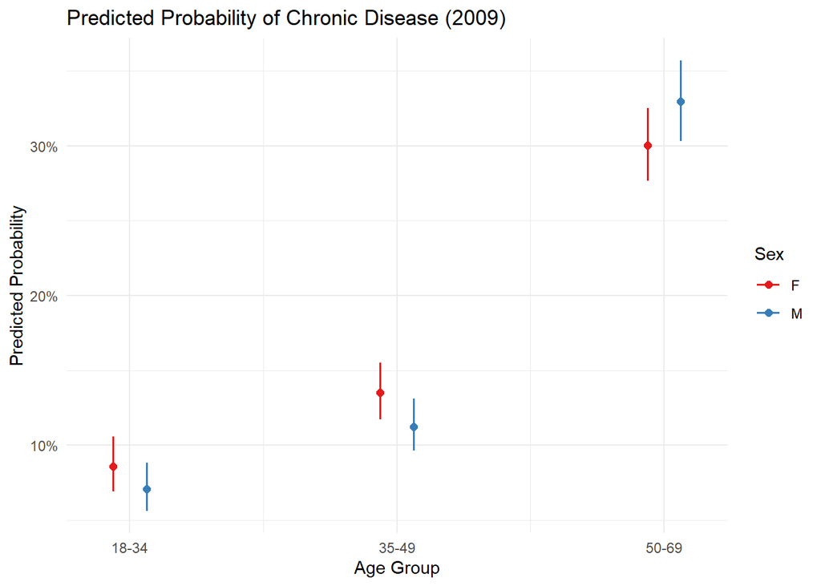

```r
# Remember that 2009 is not significant
library(ggeffects)

eff1 = ggpredict(mod_log_1b_2009, terms = c("claeta3", "sesso_intervistato", "BMI_c [0]")) # BMI is fixed at the centered value 0 (the mean of BMI_c)

plot(eff1) + labs(x = "Age Group", y = "Predicted Probability",
    title = "Predicted Probability of Chronic Disease (2009)", color = "Sex") +
  theme_minimal()
```

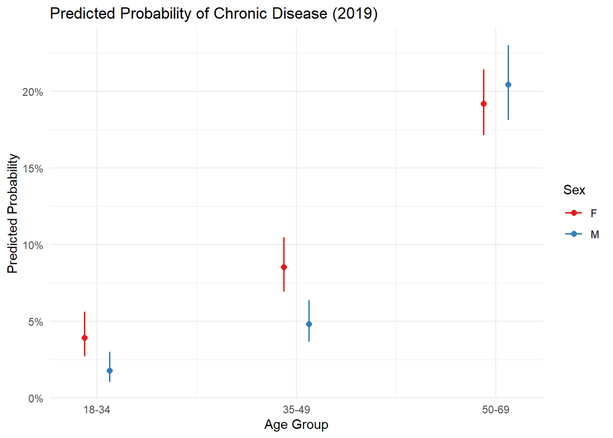

```r
eff2 = ggpredict(mod_log_1b_2019, terms = c("claeta3", "sesso_intervistato", "BMI_c [0]"))

plot(eff2) + labs(x = "Age Group", y = "Predicted Probability",
    title = "Predicted Probability of Chronic Disease (2019)", color = "Sex") +
  theme_minimal()
```

It is important to highlight that the same pattern is observed for both years. For the younger age groups, women have a higher predicted probability of having chronic diseases, whereas in the oldest age group, men show a higher predicted probability of chronic disease risk.  
**Income Level**  
Income level is included as a key socioeconomic variable because it strongly influences an individual’s ability to access healthcare services, afford nutritious food, maintain healthier lifestyles, and manage stress. These factors are all closely linked to the risk of developing chronic diseases. Therefore, controlling for income level helps to better understand its role in health outcomes and reduces confounding in the analysis.

```r
# Transform the variable so that low incomes --> high incomes
dtpa$s14_disp_econ = factor(dtpa$s14_disp_econ, levels=c(4,3,2,1))

prop.table(table(dtpa$s14_disp_econ, dtpa$malattiecroniche), 1)
```

```
##
##             0         1
##   4 0.7706741 0.2293259
##   3 0.8390575 0.1609425
##   2 0.8598915 0.1401085
##   1 0.8689581 0.1310419
```

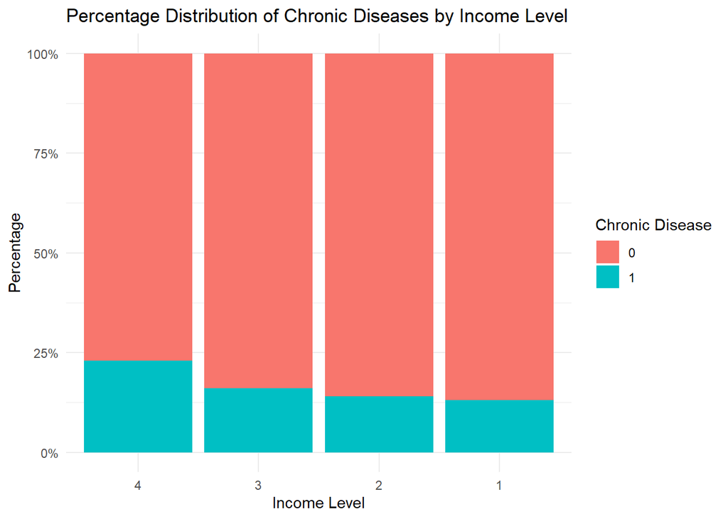

```r
ggplot(dtpa, aes(x = s14_disp_econ, fill = malattiecroniche)) +
  geom_bar(position = "fill") +
  scale_y_continuous(labels = scales::percent) +
  labs(fill = "Chronic Disease", x = "Income Level", y = "Percentage",
       title = "Percentage Distribution of Chronic Diseases by Income Level") +
  theme_minimal()
```

The original variable was reduced from four categories to two: low and high. This simplification facilitates the analysis by making it easier to interpret and manage, focusing on the main contrast between lower and higher levels.

```r
dtpa$s14_disp_econ_mod = ifelse(dtpa$s14_disp_econ == 3 |
                                dtpa$s14_disp_econ == 4, "low", "high")
dtpa$s14_disp_econ_mod = factor(dtpa$s14_disp_econ_mod, levels=c("low","high"))

prop.table(table(dtpa$s14_disp_econ_mod, dtpa$malattiecroniche), 1)
```

```
##
##                0         1
##   low  0.8237940 0.1762060
##   high 0.8610953 0.1389047
```

```r
chisq.test(table(dtpa$s14_disp_econ_mod, dtpa$malattiecroniche))
```

```
##
##  Pearson's Chi-squared test with Yates' continuity correction
##
## data:  table(dtpa$s14_disp_econ_mod, dtpa$malattiecroniche)
## X-squared = 35.071, df = 1, p-value = 3.179e-09
```

The proportion of chronic diseases differs between these groups, with 17,6% affected in the low category and 13,9% in the high. A Pearson’s chi-square test showed that this difference is statistically significant, indicating that income level is associated with chronic disease risk.

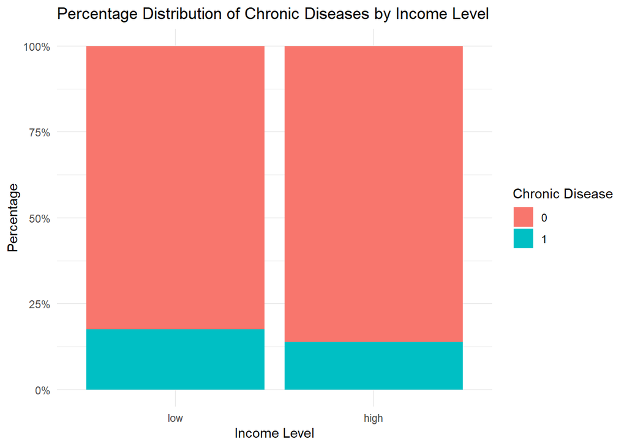

```r
ggplot(dtpa, aes(x = s14_disp_econ_mod, fill = malattiecroniche)) +
  geom_bar(position = "fill") +
  scale_y_continuous(labels = scales::percent) +
  labs(fill = "Chronic Disease", x = "Income Level", y = "Percentage",
       title = "Percentage Distribution of Chronic Diseases by Income Level") +
  theme_minimal()
```

**Education Level**  
This variable is included because education significantly influences health literacy, which in turn affects an individual’s ability to prevent diseases, manage risk factors effectively, and maintain healthy behaviors.

```r
# There are few observations for "nessun titolo", so these are combined with "licenza elementare"
dtpa$s14_tit_stud_mod = 0
dtpa$s14_tit_stud_mod[dtpa$s14_tit_stud == 1] = 2
dtpa$s14_tit_stud_mod[dtpa$s14_tit_stud == 2] = 2
dtpa$s14_tit_stud_mod[dtpa$s14_tit_stud == 3] = 3
dtpa$s14_tit_stud_mod[dtpa$s14_tit_stud == 4] = 4
dtpa$s14_tit_stud_mod[dtpa$s14_tit_stud == 5] = 5

dtpa$s14_tit_stud_mod = factor(dtpa$s14_tit_stud_mod,
                                levels = c(2, 3, 4, 5),
                                labels = c("Primary school or less",
                                           "Lower secondary",
                                           "Upper secondary",
                                           "University degree"))

prop.table(table(dtpa$s14_tit_stud_mod, dtpa$malattiecroniche), 1)
```

```
##
##                                  0         1
##   Primary school or less 0.6126205 0.3873795
##   Lower secondary        0.8161601 0.1838399
##   Upper secondary        0.8872059 0.1127941
##   University degree      0.8915254 0.1084746
```

```r
chisq.test(table(dtpa$s14_tit_stud_mod, dtpa$malattiecroniche))
```

```
##
##  Pearson's Chi-squared test
##
## data:  table(dtpa$s14_tit_stud_mod, dtpa$malattiecroniche)
## X-squared = 608.67, df = 3, p-value < 2.2e-16
```

Education level seems to be linked to the risk of chronic diseases; however, this association is likely influenced by age. Older individuals, who generally have lower average education levels, are more prone to developing chronic conditions, as previously observed.

```r
prop.table(table(dtpa$claeta3, dtpa$s14_tit_stud_mod), 2)
```

```
##
##         Primary school or less Lower secondary Upper secondary
##   18-34             0.02453988      0.17741537      0.35530132
##   35-49             0.09114812      0.35977267      0.34708347
##   50-69             0.88431201      0.46281196      0.29761521
##
##         University degree
##   18-34        0.33026634
##   35-49        0.38886199
##   50-69        0.28087167
```

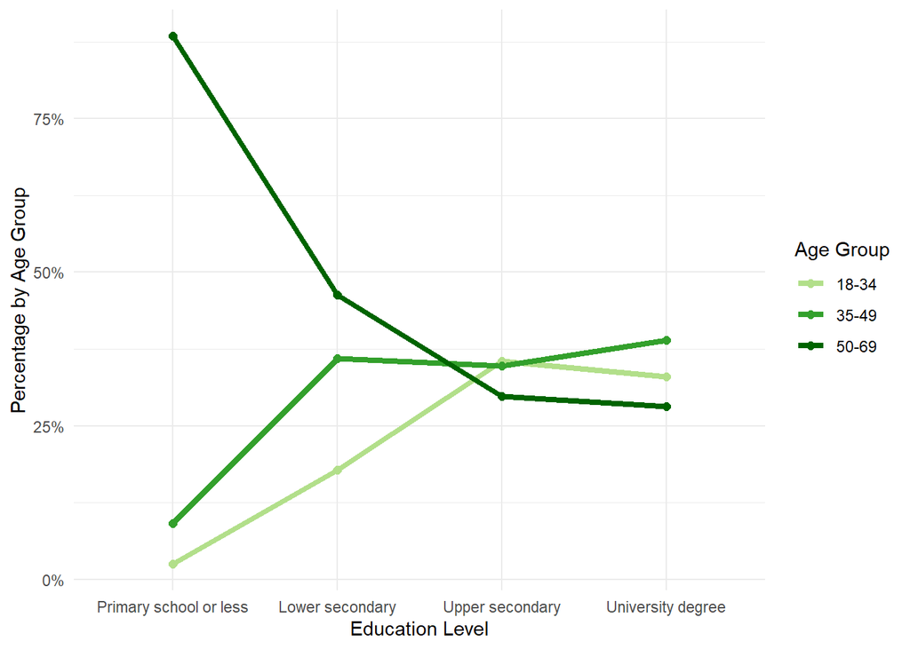

```r
plot = as.data.frame(prop.table(table(dtpa$claeta3, dtpa$s14_tit_stud_mod), 2))
colnames(plot) = c("Age_Group", "Education_Level", "Percentage")

ggplot(plot, aes(x = as.factor(Education_Level), y=Percentage, group=Age_Group, color = Age_Group)) + geom_line(linewidth = 1.5) + geom_point(size = 2) +
    scale_color_manual(values = c("#B2DF8A", "#33A02C", "#006400")) +
  scale_y_continuous(labels = scales::percent_format(accuracy = 1)) +
  labs(x = "Education Level", y = "Percentage by Age Group", color = "Age Group") + theme_minimal()
```

The education level with the highest proportions of individuals affected by chronic diseases (primary school or less, with 38,7% of individuals having at least one chronic disease) is disproportionately represented among the oldest age group. This pattern suggests that the apparent association between education and chronic disease risk may largely reflect age-related differences. Nonetheless, education will be included in the model, and its interaction with age will be explored to better understand their combined effect.  
**Citizenship**  
Citizenship status is included in the model because being a foreign citizen may affect access to the healthcare system due to potential language barriers, limited knowledge of available services, and often more precarious or physically demanding working conditions. These factors can contribute to differences in chronic disease risk.

```r
dtpa$cittadinanza[dtpa$cittadinanza == "t"] = "1"
dtpa$cittadinanza[dtpa$cittadinanza == "f"] = "2"
dtpa$cittadinanza[dtpa$cittadinanza == "3"] = "1" # Double citizenship considered as italian(1) because for 2009 this option wasn't available
dtpa$cittadinanza=factor(dtpa$cittadinanza)       # Recreate levels

prop.table(table(dtpa$cittadinanza, dtpa$malattiecroniche), 1)
```

```
##
##             0         1
##   1 0.8413339 0.1586661
##   2 0.8865248 0.1134752
```

```r
chisq.test(table(dtpa$cittadinanza, dtpa$malattiecroniche))
```

```
##
##  Pearson's Chi-squared test with Yates' continuity correction
##
## data:  table(dtpa$cittadinanza, dtpa$malattiecroniche)
## X-squared = 8.0095, df = 1, p-value = 0.004653
```

The difference in percentages between Italians and foreigners appears to be significant. Among foreigners, 11,4% have chronic diseases, whereas this percentage rises to 15,8% for Italians.  
The observed lower percentage of chronic diseases among foreigners contrasts with initial expectations. It was anticipated that factors such as language barriers and limited knowledge of the healthcare system would lead to a higher prevalence of chronic diseases in the foreign-born population. However, the data shows the opposite pattern.  
Actually, the health literature contains numerous references to the “healthy immigrant effect”. This phenomenon describes how immigrants often exhibit better initial health compared to the native population. It is thought to result from a selection bias, where healthier individuals are more likely to migrate. Additionally, cultural and language barriers, as well as limited access to healthcare, can lead to under-diagnosis or under-reporting of illnesses among immigrants, potentially masking the true extent of chronic conditions in this group.

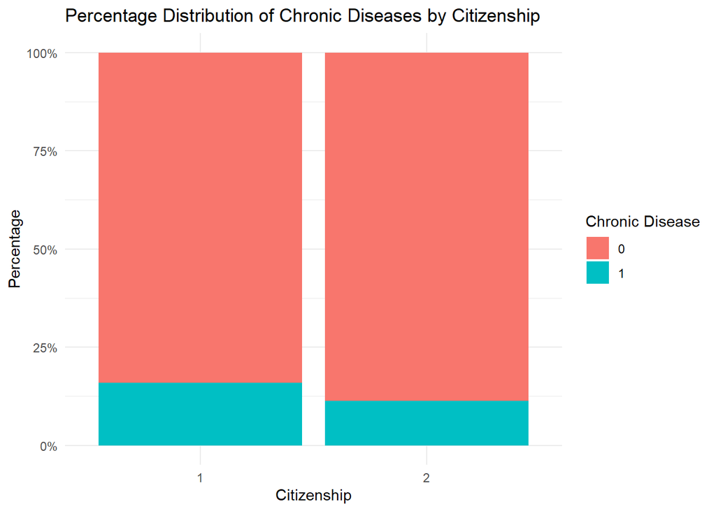

```r
ggplot(dtpa, aes(x = cittadinanza, fill = malattiecroniche)) +
  geom_bar(position = "fill") +
  scale_y_continuous(labels = scales::percent) +
  labs(fill = "Chronic Disease", x = "Citizenship", y = "Percentage",
       title = "Percentage Distribution of Chronic Diseases by Citizenship") +
  theme_minimal()
```

In addition to the healthy immigrant effect, it is important to consider that the sample is unbalanced with respect to citizenship and age:

```r
tab = prop.table(table(dtpa$claeta3, dtpa$cittadinanza), 2)
tab
```

```
##
##                 1         2
##   18-34 0.2662272 0.3546099
##   35-49 0.3316014 0.4273050
##   50-69 0.4021714 0.2180851
```

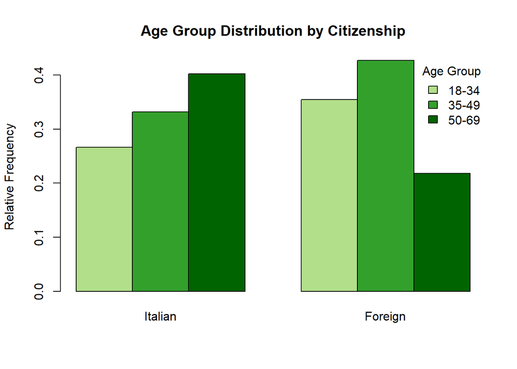

```r
barplot(tab, beside = TRUE,
        main = "Age Group Distribution by Citizenship",
        ylab = "Relative Frequency",
        legend.text = TRUE,
        args.legend = list(title = "Age Group", x = "topright", bty = "n"),
        names.arg = c("Italian", "Foreign"),
        col = c("#B2DF8A", "#33A02C", "#006400"))
```

### 2.1.2 Extended Models

The extended models retain the logistic regression structure of the basic models, adding to the original variables (BMI, sex, and age group) the newly considered factors of income level, education level, and citizenship status. This extension allows for a deeper understanding of the multiple influences on chronic disease risk.

```r
mod_log_2_2009 = glm(malattiecroniche ~ BMI + claeta3 + sesso_intervistato + s14_disp_econ_mod + s14_tit_stud_mod + cittadinanza, data = dtpa,subset = anno == 2009, family = binomial)

summary(mod_log_2_2009)
```

```
##
## Call:
## glm(formula = malattiecroniche ~ BMI + claeta3 + sesso_intervistato +
##     s14_disp_econ_mod + s14_tit_stud_mod + cittadinanza, family = binomial,
##     data = dtpa, subset = anno == 2009)
##
## Coefficients:
##                                   Estimate Std. Error z value Pr(>|z|)
## (Intercept)                       -2.87242    0.22756 -12.622  < 2e-16 ***
## BMI                                0.04184    0.00772   5.420 5.97e-08 ***
## claeta335-49                       0.47824    0.10532   4.541 5.60e-06 ***
## claeta350-69                       1.51520    0.10069  15.048  < 2e-16 ***
## sesso_intervistatoM                0.07534    0.06447   1.169   0.2425
## s14_disp_econ_modhigh             -0.19257    0.06575  -2.929   0.0034 **
## s14_tit_stud_modLower secondary   -0.43164    0.09246  -4.668 3.04e-06 ***
## s14_tit_stud_modUpper secondary   -0.66856    0.09742  -6.863 6.76e-12 ***
## s14_tit_stud_modUniversity degree -0.55822    0.13110  -4.258 2.06e-05 ***
## cittadinanza2                     -0.15846    0.19940  -0.795   0.4268
## ---
## Signif. codes:  0 '***' 0.001 '**' 0.01 '*' 0.05 '.' 0.1 ' ' 1
##
## (Dispersion parameter for binomial family taken to be 1)
##
##     Null deviance: 7166.6  on 7391  degrees of freedom
## Residual deviance: 6426.8  on 7382  degrees of freedom
## AIC: 6446.8
##
## Number of Fisher Scoring iterations: 5
```

```r
mod_log_2_2019 = glm(malattiecroniche ~ BMI + claeta3 + sesso_intervistato + s14_disp_econ_mod + s14_tit_stud_mod + cittadinanza, data = dtpa,subset = anno == 2019, family = binomial)

summary(mod_log_2_2019)
```

```
##
## Call:
## glm(formula = malattiecroniche ~ BMI + claeta3 + sesso_intervistato +
##     s14_disp_econ_mod + s14_tit_stud_mod + cittadinanza, family = binomial,
##     data = dtpa, subset = anno == 2019)
##
## Coefficients:
##                                    Estimate Std. Error z value Pr(>|z|)
## (Intercept)                       -4.090862   0.322775 -12.674  < 2e-16 ***
## BMI                                0.051850   0.009353   5.543 2.96e-08 ***
## claeta335-49                       0.878098   0.181425   4.840 1.30e-06 ***
## claeta350-69                       2.042219   0.167738  12.175  < 2e-16 ***
## sesso_intervistatoM               -0.081627   0.084663  -0.964 0.334978
## s14_disp_econ_modhigh             -0.008946   0.087812  -0.102 0.918857
## s14_tit_stud_modLower secondary   -0.522815   0.152802  -3.422 0.000623 ***
## s14_tit_stud_modUpper secondary   -0.730836   0.154754  -4.723 2.33e-06 ***
## s14_tit_stud_modUniversity degree -0.716065   0.182180  -3.931 8.48e-05 ***
## cittadinanza2                     -0.024402   0.202019  -0.121 0.903857
## ---
## Signif. codes:  0 '***' 0.001 '**' 0.01 '*' 0.05 '.' 0.1 ' ' 1
##
## (Dispersion parameter for binomial family taken to be 1)
##
##     Null deviance: 4392.0  on 6066  degrees of freedom
## Residual deviance: 3916.2  on 6057  degrees of freedom
## AIC: 3936.2
##
## Number of Fisher Scoring iterations: 6
```

In both models, education level is a significant predictor of chronic disease risk, with higher education associated with lower risk. Income level, however, is only significant in the 2009 model, where higher economic status is linked to reduced risk; it is not significant in 2019. Citizenship does not show a significant effect in either year once other variables are accounted for. BMI and age group continue to be significant predictors in both models, while sex is no longer significant in the 2019 model.

```r
coef_2009 = summary(mod_log_2_2009)$coefficients
coef_2019 = summary(mod_log_2_2019)$coefficients
confronto=data.frame("Estimate_2009" = coef_2009[, "Estimate"],
  "SE_2009" = coef_2009[, "Std. Error"],
  "Estimate_2019" = coef_2019[, "Estimate"],
  "SE_2019" = coef_2019[, "Std. Error"]
)
confronto$Differenza = confronto$Estimate_2019 - confronto$Estimate_2009
round(confronto, 3)
```

```
##                                   Estimate_2009 SE_2009 Estimate_2019 SE_2019
## (Intercept)                              -2.872   0.228        -4.091   0.323
## BMI                                       0.042   0.008         0.052   0.009
## claeta335-49                              0.478   0.105         0.878   0.181
## claeta350-69                              1.515   0.101         2.042   0.168
## sesso_intervistatoM                       0.075   0.064        -0.082   0.085
## s14_disp_econ_modhigh                    -0.193   0.066        -0.009   0.088
## s14_tit_stud_modLower secondary          -0.432   0.092        -0.523   0.153
## s14_tit_stud_modUpper secondary          -0.669   0.097        -0.731   0.155
## s14_tit_stud_modUniversity degree        -0.558   0.131        -0.716   0.182
## cittadinanza2                            -0.158   0.199        -0.024   0.202
##                                   Differenza
## (Intercept)                           -1.218
## BMI                                    0.010
## claeta335-49                           0.400
## claeta350-69                           0.527
## sesso_intervistatoM                   -0.157
## s14_disp_econ_modhigh                  0.184
## s14_tit_stud_modLower secondary       -0.091
## s14_tit_stud_modUpper secondary       -0.062
## s14_tit_stud_modUniversity degree     -0.158
## cittadinanza2                          0.134
```

```r
mod_log_2b_2009 = glm(malattiecroniche ~ BMI + claeta3 + sesso_intervistato + s14_disp_econ_mod + s14_tit_stud_mod*claeta3 + cittadinanza*claeta3, data = dtpa,subset = anno == 2009, family = binomial)

summary(mod_log_2b_2009)
```

```
##
## Call:
## glm(formula = malattiecroniche ~ BMI + claeta3 + sesso_intervistato +
##     s14_disp_econ_mod + s14_tit_stud_mod * claeta3 + cittadinanza *
##     claeta3, family = binomial, data = dtpa, subset = anno ==
##     2009)
##
## Coefficients:
##                                                 Estimate Std. Error z value
## (Intercept)                                    -3.432173   0.784008  -4.378
## BMI                                             0.042607   0.007762   5.489
## claeta335-49                                    1.411904   0.808130   1.747
## claeta350-69                                    2.031788   0.759401   2.676
## sesso_intervistatoM                             0.083475   0.064790   1.288
## s14_disp_econ_modhigh                          -0.185856   0.065852  -2.822
## s14_tit_stud_modLower secondary                 0.082605   0.768252   0.108
## s14_tit_stud_modUpper secondary                -0.180989   0.762543  -0.237
## s14_tit_stud_modUniversity degree               0.154637   0.780283   0.198
## cittadinanza2                                   0.012088   0.365445   0.033
## claeta335-49:s14_tit_stud_modLower secondary   -1.086363   0.824823  -1.317
## claeta350-69:s14_tit_stud_modLower secondary   -0.401845   0.774633  -0.519
## claeta335-49:s14_tit_stud_modUpper secondary   -0.724515   0.818072  -0.886
## claeta350-69:s14_tit_stud_modUpper secondary   -0.574074   0.770201  -0.745
## claeta335-49:s14_tit_stud_modUniversity degree -1.177308   0.848577  -1.387
## claeta350-69:s14_tit_stud_modUniversity degree -0.742705   0.797214  -0.932
## claeta335-49:cittadinanza2                     -0.434143   0.494724  -0.878
## claeta350-69:cittadinanza2                     -0.096074   0.510730  -0.188
##                                                Pr(>|z|)
## (Intercept)                                    1.20e-05 ***
## BMI                                            4.04e-08 ***
## claeta335-49                                    0.08062 .
## claeta350-69                                    0.00746 **
## sesso_intervistatoM                             0.19761
## s14_disp_econ_modhigh                           0.00477 **
## s14_tit_stud_modLower secondary                 0.91437
## s14_tit_stud_modUpper secondary                 0.81239
## s14_tit_stud_modUniversity degree               0.84290
## cittadinanza2                                   0.97361
## claeta335-49:s14_tit_stud_modLower secondary    0.18781
## claeta350-69:s14_tit_stud_modLower secondary    0.60393
## claeta335-49:s14_tit_stud_modUpper secondary    0.37581
## claeta350-69:s14_tit_stud_modUpper secondary    0.45606
## claeta335-49:s14_tit_stud_modUniversity degree  0.16532
## claeta350-69:s14_tit_stud_modUniversity degree  0.35153
## claeta335-49:cittadinanza2                      0.38019
## claeta350-69:cittadinanza2                      0.85079
## ---
## Signif. codes:  0 '***' 0.001 '**' 0.01 '*' 0.05 '.' 0.1 ' ' 1
##
## (Dispersion parameter for binomial family taken to be 1)
##
##     Null deviance: 7166.6  on 7391  degrees of freedom
## Residual deviance: 6412.8  on 7374  degrees of freedom
## AIC: 6448.8
##
## Number of Fisher Scoring iterations: 5
```

```r
mod_log_2b_2019 = glm(malattiecroniche ~ BMI + claeta3 + sesso_intervistato + s14_disp_econ_mod + s14_tit_stud_mod + cittadinanza*claeta3, data = dtpa,subset = anno == 2019, family = binomial)
# Multicollinearity problem for 2019: removed interaction between age and education level

summary(mod_log_2b_2019)
```

```
##
## Call:
## glm(formula = malattiecroniche ~ BMI + claeta3 + sesso_intervistato +
##     s14_disp_econ_mod + s14_tit_stud_mod + cittadinanza * claeta3,
##     family = binomial, data = dtpa, subset = anno == 2019)
##
## Coefficients:
##                                    Estimate Std. Error z value Pr(>|z|)
## (Intercept)                       -4.133774   0.326938 -12.644  < 2e-16 ***
## BMI                                0.051982   0.009361   5.553 2.80e-08 ***
## claeta335-49                       0.925250   0.189917   4.872 1.11e-06 ***
## claeta350-69                       2.085749   0.175427  11.890  < 2e-16 ***
## sesso_intervistatoM               -0.082015   0.084699  -0.968 0.332890
## s14_disp_econ_modhigh             -0.010141   0.087837  -0.115 0.908086
## s14_tit_stud_modLower secondary   -0.525084   0.152939  -3.433 0.000596 ***
## s14_tit_stud_modUpper secondary   -0.731496   0.155032  -4.718 2.38e-06 ***
## s14_tit_stud_modUniversity degree -0.715348   0.182605  -3.917 8.95e-05 ***
## cittadinanza2                      0.529651   0.539058   0.983 0.325830
## claeta335-49:cittadinanza2        -0.633076   0.639883  -0.989 0.322486
## claeta350-69:cittadinanza2        -0.618916   0.604460  -1.024 0.305875
## ---
## Signif. codes:  0 '***' 0.001 '**' 0.01 '*' 0.05 '.' 0.1 ' ' 1
##
## (Dispersion parameter for binomial family taken to be 1)
##
##     Null deviance: 4392.0  on 6066  degrees of freedom
## Residual deviance: 3915.2  on 6055  degrees of freedom
## AIC: 3939.2
##
## Number of Fisher Scoring iterations: 6
```

Including interaction terms between education and age group, as well as between citizenship and age group, did not improve the explanatory power of the models for either 2009 or 2019. None of the interaction effects were statistically significant, suggesting that the relationship between these covariates and the probability of having chronic diseases does not vary meaningfully across age groups.  
Moreover, the addition of interactions increased model complexity without substantial benefits. For instance, education (which was previously a significant predictor in 2009) lost its significance in the extended model, likely due to increased variance and multicollinearity.  
Overall, the extended models appear to overcomplicate the analysis without providing additional insight.

### 2.1.3 Model comparison and selection

The purpose of comparing the logistic regression models is to identify the best-fitting model for each year separately. It is important to emphasize that the optimal model structure for 2009 may differ from that for 2019, reflecting potential changes in the relationships between variables over time.  
When the models being compared are nested, meaning one model is a simplified version of the other, the likelihood ratio test (lrtest() function) is used to check if the more complex model fits the data significantly better. For models that are not nested, the Akaike Information Criterion (AIC) is used to compare them, and the model with the lower AIC value is chosen as the better one.

```r
# 2009
AIC(mod_log_1_2009)
```

```
## [1] 6502.939
```

```r
AIC(mod_log_1b_2009) # Mod_log_1b_2009 is better
```

```
## [1] 6500.469
```

```r
AIC(mod_log_2_2009) # Mod_log_2_2009 is better
```

```
## [1] 6446.833
```

```r
lrtest(mod_log_2_2009, mod_log_2b_2009) # Not significant at 5%
```

```
## Likelihood ratio test
##
## Model 1: malattiecroniche ~ BMI + claeta3 + sesso_intervistato + s14_disp_econ_mod +
##     s14_tit_stud_mod + cittadinanza
## Model 2: malattiecroniche ~ BMI + claeta3 + sesso_intervistato + s14_disp_econ_mod +
##     s14_tit_stud_mod * claeta3 + cittadinanza * claeta3
##   #Df  LogLik Df  Chisq Pr(>Chisq)
## 1  10 -3213.4
## 2  18 -3206.4  8 14.028    0.08104 .
## ---
## Signif. codes:  0 '***' 0.001 '**' 0.01 '*' 0.05 '.' 0.1 ' ' 1
```

```r
AIC(mod_log_2b_2009) # AIC confirms: mod_log_2_2009 remains better
```

```
## [1] 6448.805
```

```r
# 2019
AIC(mod_log_1_2019)
```

```
## [1] 3949.959
```

```r
AIC(mod_log_1b_2019) # Mod_log_1b_2019 is better
```

```
## [1] 3939.247
```

```r
AIC(mod_log_2_2019) # Mod_log_2_2019 is better
```

```
## [1] 3936.234
```

```r
lrtest(mod_log_2_2019, mod_log_2b_2019) # Mod_log_2_2019 remains better
```

```
## Likelihood ratio test
##
## Model 1: malattiecroniche ~ BMI + claeta3 + sesso_intervistato + s14_disp_econ_mod +
##     s14_tit_stud_mod + cittadinanza
## Model 2: malattiecroniche ~ BMI + claeta3 + sesso_intervistato + s14_disp_econ_mod +
##     s14_tit_stud_mod + cittadinanza * claeta3
##   #Df  LogLik Df  Chisq Pr(>Chisq)
## 1  10 -1958.1
## 2  12 -1957.6  2 1.0341     0.5963
```

For 2009, the model mod_log_2_2009 is considered.  
For 2019, based on the comparisons performed, the model mod_log_2_2019 appears to be slightly better; however, it does not include the sex*age interaction, which was significant in the mod_log_1b_2019 model. Therefore, it was decided to consider the latter model and add education level as a covariate. This results in the best possible model:

```r
mod_top_2019 = glm(formula = malattiecroniche ~ BMI_c * sesso_intervistato +
    claeta3 * sesso_intervistato + s14_tit_stud_mod, family = binomial, data = dtpa, subset = anno == 2019)

summary(mod_top_2019)
```

```
##
## Call:
## glm(formula = malattiecroniche ~ BMI_c * sesso_intervistato +
##     claeta3 * sesso_intervistato + s14_tit_stud_mod, family = binomial,
##     data = dtpa, subset = anno == 2019)
##
## Coefficients:
##                                   Estimate Std. Error z value Pr(>|z|)
## (Intercept)                       -2.49070    0.24042 -10.360  < 2e-16 ***
## BMI_c                              0.04817    0.01156   4.167 3.08e-05 ***
## sesso_intervistatoM               -0.80230    0.33215  -2.415 0.015714 *
## claeta335-49                       0.79981    0.22504   3.554 0.000379 ***
## claeta350-69                       1.63698    0.20921   7.824 5.10e-15 ***
## s14_tit_stud_modLower secondary   -0.54138    0.15226  -3.556 0.000377 ***
## s14_tit_stud_modUpper secondary   -0.75191    0.15241  -4.933 8.08e-07 ***
## s14_tit_stud_modUniversity degree -0.75678    0.17762  -4.261 2.04e-05 ***
## BMI_c:sesso_intervistatoM          0.01156    0.01914   0.604 0.545838
## sesso_intervistatoM:claeta335-49   0.19634    0.38134   0.515 0.606654
## sesso_intervistatoM:claeta350-69   0.91681    0.34872   2.629 0.008561 **
## ---
## Signif. codes:  0 '***' 0.001 '**' 0.01 '*' 0.05 '.' 0.1 ' ' 1
##
## (Dispersion parameter for binomial family taken to be 1)
##
##     Null deviance: 4392.0  on 6066  degrees of freedom
## Residual deviance: 3898.2  on 6056  degrees of freedom
## AIC: 3920.2
##
## Number of Fisher Scoring iterations: 6
```

```r
AIC(mod_log_2_2019)
```

```
## [1] 3936.234
```

```r
AIC(mod_top_2019)
```

```
## [1] 3920.166
```

### 2.1.4 Model Interpretation

**2009**:

```r
summary(mod_log_2_2009)
```

```
##
## Call:
## glm(formula = malattiecroniche ~ BMI + claeta3 + sesso_intervistato +
##     s14_disp_econ_mod + s14_tit_stud_mod + cittadinanza, family = binomial,
##     data = dtpa, subset = anno == 2009)
##
## Coefficients:
##                                   Estimate Std. Error z value Pr(>|z|)
## (Intercept)                       -2.87242    0.22756 -12.622  < 2e-16 ***
## BMI                                0.04184    0.00772   5.420 5.97e-08 ***
## claeta335-49                       0.47824    0.10532   4.541 5.60e-06 ***
## claeta350-69                       1.51520    0.10069  15.048  < 2e-16 ***
## sesso_intervistatoM                0.07534    0.06447   1.169   0.2425
## s14_disp_econ_modhigh             -0.19257    0.06575  -2.929   0.0034 **
## s14_tit_stud_modLower secondary   -0.43164    0.09246  -4.668 3.04e-06 ***
## s14_tit_stud_modUpper secondary   -0.66856    0.09742  -6.863 6.76e-12 ***
## s14_tit_stud_modUniversity degree -0.55822    0.13110  -4.258 2.06e-05 ***
## cittadinanza2                     -0.15846    0.19940  -0.795   0.4268
## ---
## Signif. codes:  0 '***' 0.001 '**' 0.01 '*' 0.05 '.' 0.1 ' ' 1
##
## (Dispersion parameter for binomial family taken to be 1)
##
##     Null deviance: 7166.6  on 7391  degrees of freedom
## Residual deviance: 6426.8  on 7382  degrees of freedom
## AIC: 6446.8
##
## Number of Fisher Scoring iterations: 5
```

The coefficients are in log-odds form, so we exponentiate them to interpret effects as odds ratios. Significant coefficients indicate predictors that have a meaningful association with the outcome.  
In particular, for each one-unit increase in BMI, the odds of having a chronic disease increase by approximately 4,3% (because exp(0.04184) = 1.0427).  
Being in the middle (35-49) age group (compared to the baseline age group 18-34) increases the odds of chronic disease by about 61,3%. Being in the oldest age group increases the same odds by approximately 355%. Older age strongly increases the risk of chronic diseases. Having a high income level decreases the odds of chronic diseases by about 17,5%.  
Compared to the baseline (primary school or less), higher education levels significantly decrease the odds of chronic diseases:  
• **Lower secondary**: 35,3% decrease in odds;  
• **Upper secondary**: 49,0% decrease in odds;  
• **University degree**: 42,9% decrease in odds.  
It is possible to conclude that higher education is protective against chronic diseases.  
**2019**:

```r
summary(mod_top_2019)
```

```
##
## Call:
## glm(formula = malattiecroniche ~ BMI_c * sesso_intervistato +
##     claeta3 * sesso_intervistato + s14_tit_stud_mod, family = binomial,
##     data = dtpa, subset = anno == 2019)
##
## Coefficients:
##                                   Estimate Std. Error z value Pr(>|z|)
## (Intercept)                       -2.49070    0.24042 -10.360  < 2e-16 ***
## BMI_c                              0.04817    0.01156   4.167 3.08e-05 ***
## sesso_intervistatoM               -0.80230    0.33215  -2.415 0.015714 *
## claeta335-49                       0.79981    0.22504   3.554 0.000379 ***
## claeta350-69                       1.63698    0.20921   7.824 5.10e-15 ***
## s14_tit_stud_modLower secondary   -0.54138    0.15226  -3.556 0.000377 ***
## s14_tit_stud_modUpper secondary   -0.75191    0.15241  -4.933 8.08e-07 ***
## s14_tit_stud_modUniversity degree -0.75678    0.17762  -4.261 2.04e-05 ***
## BMI_c:sesso_intervistatoM          0.01156    0.01914   0.604 0.545838
## sesso_intervistatoM:claeta335-49   0.19634    0.38134   0.515 0.606654
## sesso_intervistatoM:claeta350-69   0.91681    0.34872   2.629 0.008561 **
## ---
## Signif. codes:  0 '***' 0.001 '**' 0.01 '*' 0.05 '.' 0.1 ' ' 1
##
## (Dispersion parameter for binomial family taken to be 1)
##
##     Null deviance: 4392.0  on 6066  degrees of freedom
## Residual deviance: 3898.2  on 6056  degrees of freedom
## AIC: 3920.2
##
## Number of Fisher Scoring iterations: 6
```

Each 1-unit increase in BMI above the mean (because the variable is centered) increases the odds of chronic diseases by about 4,9% (similar to 2009).  
Males have about 55% lower odds of chronic diseases compared to females when BMI is average and other covariates at baseline.  
The effect of age on chronic diseases became stronger in 2019 because, compared to the youngest age group:  
• **Middle age group (35-49)** increases odds by 122%;  
• **Oldest group (50-69)** increases odds by 414%.  
In addition, considering the significant interaction coefficient, for males in the oldest age group, odds are increased by an additional 151% compared to females in the same age group. This means older males have a much higher risk compared to older females in 2019.  
Education remains a protective factor, with slightly larger reductions in odds in 2019, 42% for Lower secondary, 53% for both Upper secondary and University degree.

## 2.2 Generalized Linear Mixed Models (GLMM)

The dependent variable remains unchanged, indicating whether an individual has at least one chronic disease (value 1). In this analysis, geographical factors such as regions or local health authorities (ASL) are included as random effects to account for variability across areas. Moreover, the year is now incorporated as a fixed effect within the model, allowing us to examine temporal trends while properly accounting for the hierarchical structure of the data.  
This model includes the variable year as well as the covariates from the basic model: BMI, age group, and sex.  
The objective is to identify the model whose random effect best explains the data. Therefore, models will be considered with random effects for ASL, for regions, and one including the macroarea covariate.

```r
dtpa$anno = as.integer(as.character(dtpa$anno))
dtpa$anno_c = dtpa$anno - mean(dtpa$anno) # Year centered for converge failure

dtpa$asl = as.factor(dtpa$asl)

glmm_1 = glmer(dtpa$malattiecroniche ~ BMI_c + claeta3 + sesso_intervistato + anno_c + (1 | asl), data = dtpa, family = binomial)
# Summary(glmm_1)
parameters::random_parameters(glmm_1)
```

```
## # Random Effects
##
## Within-Group Variance      3.29 (1.81)
## Between-Group Variance
##   Random Intercept (asl)   0.03 (0.16)
## N (groups per factor)
##   asl                       209
## Observations              13459
```

```r
glmm_2 = glmer(malattiecroniche ~ BMI_c + claeta3 + sesso_intervistato+anno_c +
                    (1 | regione), data = dtpa, family = binomial)
# Summary(glmm_2)
parameters::random_parameters(glmm_2)
```

```
## # Random Effects
##
## Within-Group Variance          3.29 (1.81)
## Between-Group Variance
##   Random Intercept (regione)      0 (0.06)
## N (groups per factor)
##   regione                        21
## Observations                  13459
```

In the model with random intercepts at the ASL level, although the variance of the random effect is small (0.03), it is different from zero, indicating the presence of variability among ASLs that contributes to the model. Conversely, in the model with random intercepts at the Region level, the variance of the random effect is essentially zero, suggesting that differences between Regions do not significantly explain variability in the data. Therefore, it is more appropriate to retain the random effect at the ASL level rather than at the Region level.

```r
AIC(glmm_1, glmm_2)
```

```
##        df      AIC
## glmm_1  7 10450.20
## glmm_2  7 10453.98
```

The AIC values confirm this reasoning, with the model including the random effect at the ASL level showing better fit compared to the model with the random effect at the Region level.  
Now, the best model (ASL as random effect) will be extended by adding a covariate for the macroarea.

```r
dtpa$macroarea = NA
dtpa$macroarea[dtpa$regione %in% c("Piemonte", "Valle D'Aosta", "Lombardia",
                                   "Veneto", "Friuli Venezia Giulia",
                                   "Liguria", "Emilia-Romagna", "Trentino",
                                   "Alto Adige")] = "NORD"
dtpa$macroarea[dtpa$regione %in% c("Toscana", "Umbria", "Marche", "Lazio")] = "CENTRO"
dtpa$macroarea[dtpa$regione %in% c("Abruzzo", "Molise", "Campania", "Puglia",
                                   "Basilicata", "Calabria", "Sicilia",
                                   "Sardegna")] = "SUD"
dtpa$macroarea = factor(dtpa$macroarea, levels = c("NORD", "CENTRO", "SUD"))


glmm_3 = glmer(malattiecroniche ~ BMI_c + claeta3 + sesso_intervistato + anno_c + macroarea + (1 | asl), data = dtpa, family = binomial)
summary(glmm_3)$coefficients[c(7,8),]
```

```
##                    Estimate Std. Error    z value  Pr(>|z|)
## macroareaCENTRO  0.02793617 0.06888803  0.4055300 0.6850879
## macroareaSUD    -0.01249503 0.06784742 -0.1841637 0.8538851
```

```r
parameters::random_parameters(glmm_3)
```

```
## # Random Effects
##
## Within-Group Variance      3.29 (1.81)
## Between-Group Variance
##   Random Intercept (asl)   0.03 (0.16)
## N (groups per factor)
##   asl                       209
## Observations              13459
```

```r
AIC(glmm_3)
```

```
## [1] 10453.91
```

The differences between the two models are minimal, and the macroarea covariate in model glmm_3 is not statistically significant. Once we control for age, sex, BMI, year, and include a random intercept for ASL, no significant differences emerge in the risk of chronic diseases across macroareas. Therefore, for the sake of simplicity, model glmm_1 is preferred. Moreover, the AIC of glmm_3 is higher than that of glmm_1, further supporting the preference for the more parsimonious model.

### 2.2.1 Model Interpretation

Each point on the following plot represents the estimated effect of a predictor on the likelihood of having at least one chronic disease, while holding the other variables constant.

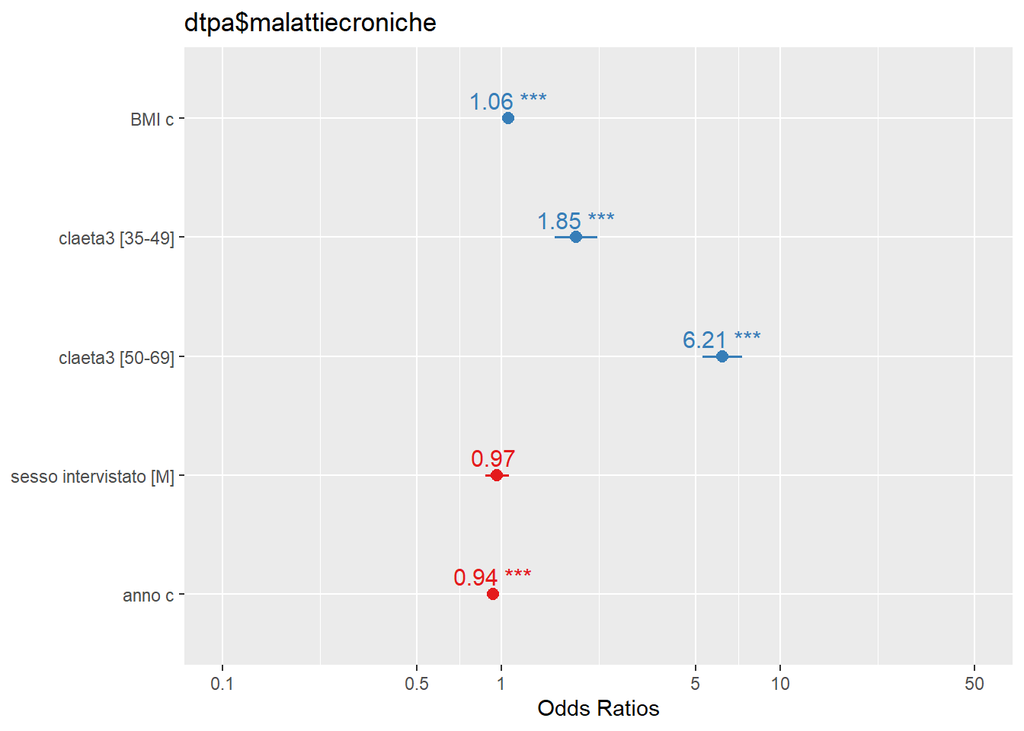

```r
sjPlot::plot_model(glmm_1, show.values = TRUE,show.p=TRUE)
```

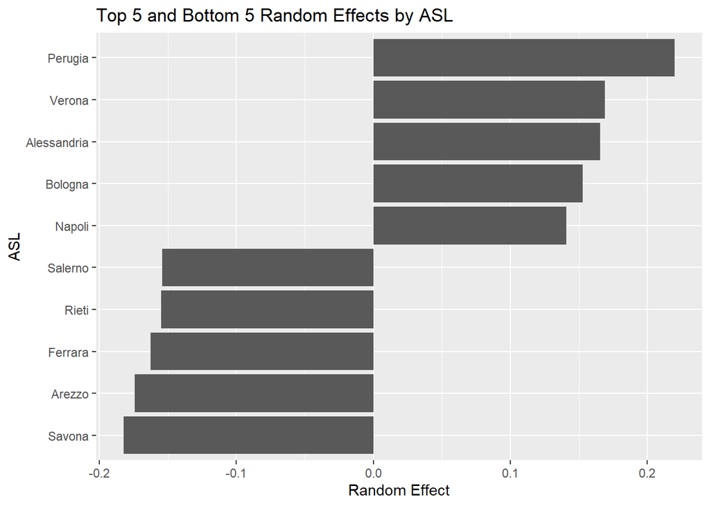

```r
re = ranef(glmm_1)$asl
re_df = data.frame(asl = rownames(re), intercept = re[,1])

top5 = tail(re_df[order(re_df$intercept), ], 5)
bottom5 = head(re_df[order(re_df$intercept), ], 5)
extremes = rbind(top5, bottom5)

etichette = c("Savona", "Arezzo", "Ferrara", "Rieti", "Salerno", "Napoli", "Bologna", "Alessandria", "Verona", "Perugia")

ggplot(extremes, aes(x = reorder(asl, intercept), y = intercept)) +
  geom_col() +
  coord_flip() +
  scale_x_discrete(labels = etichette) +
  labs(title = "Top 5 and Bottom 5 Random Effects by ASL",
       x = "ASL", y = "Random Effect")
```

## 2.3 Count Data Models: Poisson and Negative Binomial Regression

In this section, we model the number of chronic diseases using count data regression techniques. To do so, we first created a new variable that counts the total number of chronic diseases reported by each individual:
$$Y_i = D_{i} + R_{i} + B_{i} + M_{i} + T_{i}$$
where each dummy variable assumes the value:
$$X_i =
\begin{cases}
1 & \text{if individual } i \text{ has the condition} \\
0 & \text{otherwise}
\end{cases}$$

```r
dtpa = dtpa %>%
  mutate(
    s01_diabete = ifelse(s01_diabete == "t", 1, 0),
    s01_insuff_renale = ifelse(s01_insuff_renale == "t", 1, 0),
    s01_bronchite = ifelse(s01_bronchite == "t", 1, 0),
    s01_ima = ifelse(s01_ima == "t", 1, 0),
    s01_tumori = ifelse(s01_tumori == "t", 1, 0)
  )

dtpa$count_malattie =
  dtpa$s01_diabete +
  dtpa$s01_insuff_renale +
  dtpa$s01_bronchite +
  dtpa$s01_ima +
  dtpa$s01_tumori
```

The mean and variance of the count variable representing the number of chronic diseases are calculated to assess the appropriate count model:

```r
mean(dtpa$count_malattie)
```

```
## [1] 0.1887213
```

```r
var(dtpa$count_malattie)
```

```
## [1] 0.2344069
```

The Poisson distribution assumes equality between mean and variance. When the variance exceeds the mean (overdispersion), the Negative Binomial model is typically preferred as it accounts for extra variability.  
Given that the data is near this borderline, both Poisson and Negative Binomial models will be fitted and subsequently compared to determine the better fit.  
As in the case of the GLMM, here too the covariates considered are those from the basic model, namely BMI, age, and sex.

```r
pois = glm(count_malattie ~ BMI + claeta3 + sesso_intervistato + anno,
                family = poisson(link = "log"), data = dtpa)
AIC(pois)
```

```
## [1] 12809.08
```

```r
library(MASS)
nb = glm.nb(count_malattie ~ BMI + claeta3 + sesso_intervistato + anno,
                 data = dtpa)
AIC(nb)
```

```
## [1] 12762.25
```

A lower AIC indicates a better model in terms of the trade-off between goodness of fit and model complexity. Therefore, the Negative Binomial model is preferred and will be used for further considerations.

### 2.3.1 Model Interpretation

```r
summary(nb)
```

```
##
## Call:
## glm.nb(formula = count_malattie ~ BMI + claeta3 + sesso_intervistato +
##     anno, data = dtpa, init.theta = 2.604092014, link = log)
##
## Coefficients:
##                       Estimate Std. Error z value Pr(>|z|)
## (Intercept)         109.106765   8.905910  12.251  < 2e-16 ***
## BMI                   0.049067   0.004602  10.663  < 2e-16 ***
## claeta335-49          0.562191   0.082669   6.801 1.04e-11 ***
## claeta350-69          1.622443   0.074520  21.772  < 2e-16 ***
## sesso_intervistatoM   0.005824   0.042194   0.138     0.89
## anno                 -0.056185   0.004425 -12.697  < 2e-16 ***
## ---
## Signif. codes:  0 '***' 0.001 '**' 0.01 '*' 0.05 '.' 0.1 ' ' 1
##
## (Dispersion parameter for Negative Binomial(2.6041) family taken to be 1)
##
##     Null deviance: 8793.4  on 13458  degrees of freedom
## Residual deviance: 7461.1  on 13453  degrees of freedom
## AIC: 12762
##
## Number of Fisher Scoring iterations: 1
##
##
##               Theta:  2.604
##           Std. Err.:  0.449
##
##  2 x log-likelihood:  -12748.250
```

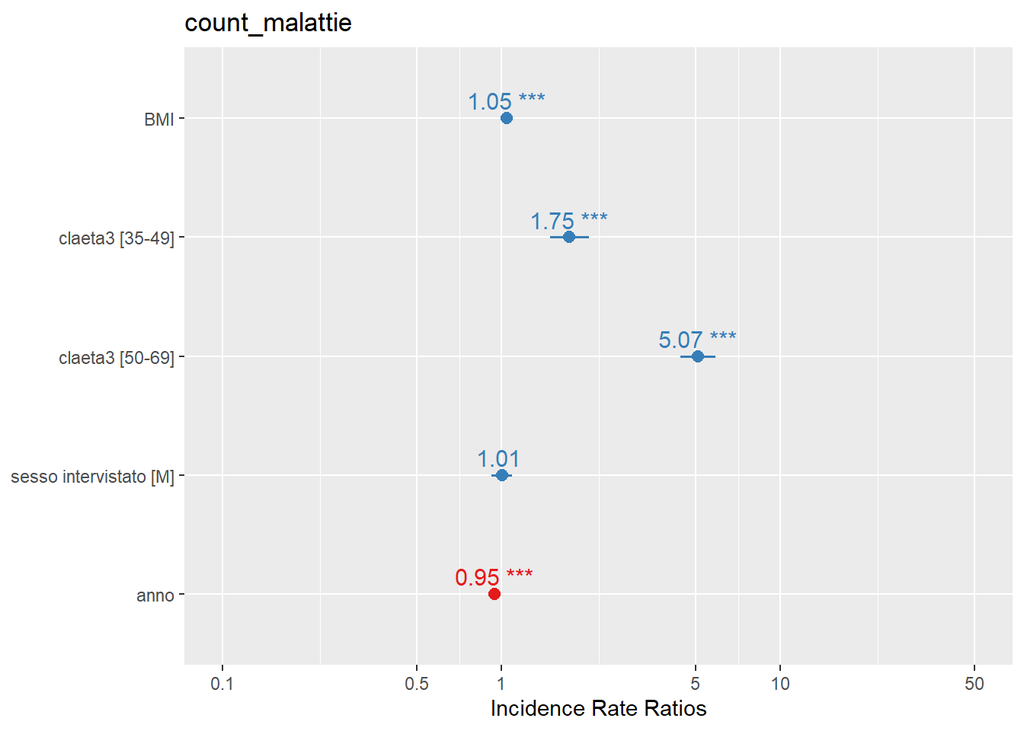

```r
sjPlot::plot_model(nb, show.values = TRUE, show.p = TRUE)
```

# 3 Cardiovascular Risk in relation to the quantity of Cigarettes smoked and Alcohol consumption

In this part we wanted to analyse how the number of cigarettes smoked and alcohol consumption can influence or not the cardiovascular risk of each subject.
To do this we analysed the variable `cardiovasc`:
$$\text{cardiovasc}_i =
\begin{cases}
1 & \text{if a doctor has ever calculated the risk} \\
0 & \text{if the subject is not at risk}
\end{cases}$$
(i.e. whether a doctor had ever attributed cardiovascular risk to a certain subject).
Always taking as a reference the four variable on which we built the sample (year, ASL, sex and age classes) we first analysed the two risk factors separately, i.e. the number of cigarettes smoked and the amount of alcohol consumed. Subsequently, we graphically represented the distribution of the cardiovascular risk both by region and by ASL.
Finally we analysed how the two variables mentioned above could be significant for cardiovascular risk.

```r
Cigarettes_Alcohol = dataset_definitivo %>%
  dplyr::select(anno:s01_vaccin_ultima,
                s03_fumo_chiesto:s03_fumo_lavoro,
                s05_alcool_gg:s05_alcool_sugg_non_so,
                s07_press_mis:s07_calc_risc,cardiovasc)

# Since there are many observations in the dataset that take the value of -99 (for the answers "I don't know/I don't remember"), we consider them as NA.
Cigarettes_Alcohol[Cigarettes_Alcohol == -99] = NA

# Change age classes so that year ranges are visible
Cigarettes_Alcohol$claeta3= ifelse(Cigarettes_Alcohol$claeta3 == 1, '18-34',
                                   ifelse(Cigarettes_Alcohol$claeta3 == 2, '35-49',
                                          ifelse(Cigarettes_Alcohol$claeta3 == 3, '50-69', NA)))
```

## 3.1 Cigarette Consumption

As regards cigarette consumption, the analysis focuses first on the **smoking status** between the two reference years and between the two sexes.  
Then we go into specifics by analysing how the **number of cigarettes smoked per day** varies among subjects who are actually smokers, making a comparison not only between sex and year, but also taking age classes as reference.

### 3.1.1 Smoking Status

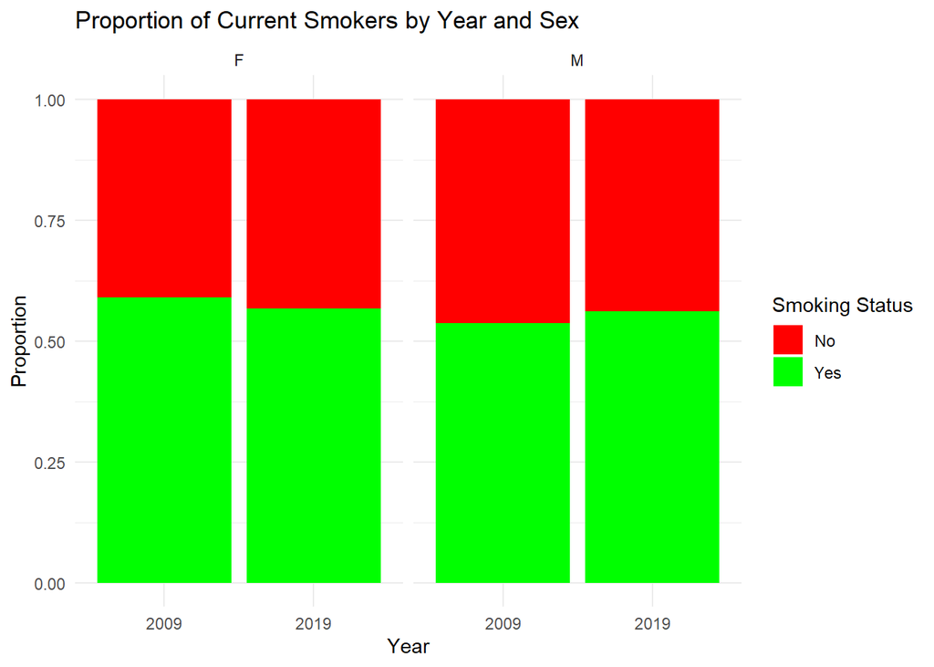

```
## , ,  = No
##
##
##           F    M
##   2009 41.0 46.3
##   2019 43.3 43.8
##
## , ,  = Yes
##
##
##           F    M
##   2009 59.0 53.7
##   2019 56.7 56.2
```

```r
# Since for the variable `s03_fumo_att` the observations take the values of t and f, we change them to Yes or No, in order to have a more correct graphic representation
Cigarettes_Alcohol$s03_fumo_att = ifelse(Cigarettes_Alcohol$s03_fumo_att == 't', 'Yes',
                                         ifelse(Cigarettes_Alcohol$s03_fumo_att == 'f', 'No', NA))

# Barplot for current smoking status by year and sex
ggplot(Cigarettes_Alcohol %>% filter(!is.na(s03_fumo_att)), aes(x = as.factor(anno), fill = s03_fumo_att)) +
  geom_bar(position = "fill") +
  facet_wrap(~ sesso_intervistato) +
  labs(title = "Proportion of Current Smokers by Year and Sex", x = "Year", y = "Proportion", fill = "Smoking Status") +
  scale_fill_manual(values = c("Yes" = "green", "No" = "red")) +
  theme_minimal()
```

The bar chart illustrates the proportion of current smokers by year and sex, distinguishing between smokers (*Yes*) and non-smokers (*No*). Each bar represents the relative proportion within each subgroup, with the total summing to 100%.  
From the visual, we observe that in both years, the proportion of smokers is more or less the same among males and females and for both years, suggesting that the prevalence of smoking did not change substantially over the decade in either group. Only in 2009 the number of female smokers (~58,99%) is higher than that of males (~53,66%).  
For **females**, the proportion of smokers appears slightly lower in 2019 compared to 2009, indicating a modest decline. In contrast, among **males**, the proportion remains nearly stable or even shows a slight increase in 2019. Despite public health efforts to reduce smoking, the data suggests that behavioral change was limited over the 10-year-period, especially among men.  
A **logistic regression** with the `glm()` function with a binomial family was fitted to investigate the relationship between smoking status and demographic variables. The dependent variable is `s03_fumo_att` and the independent variables are `anno` and `sesso_intervistato`.

```r
# Modifying the values of the variable `s03_fumo_att` for the creation of the statistical model
Cigarettes_Alcohol$s03_fumo_att = ifelse(Cigarettes_Alcohol$s03_fumo_att == 'Yes', 1,
                                         ifelse(Cigarettes_Alcohol$s03_fumo_att == 'No', 0, NA))

Model_Smoke_Status = glm(Cigarettes_Alcohol$s03_fumo_att ~ as.factor(Cigarettes_Alcohol$anno) + as.factor(Cigarettes_Alcohol$sesso_intervistato),
                  family = binomial,
                  na.action = na.omit)
```

```
##
## Call:
## glm(formula = Cigarettes_Alcohol$s03_fumo_att ~ as.factor(Cigarettes_Alcohol$anno) +
##     as.factor(Cigarettes_Alcohol$sesso_intervistato), family = binomial,
##     na.action = na.omit)
##
## Coefficients:
##                                                   Estimate Std. Error z value
## (Intercept)                                        0.31388    0.04542   6.910
## as.factor(Cigarettes_Alcohol$anno)2019             0.02080    0.05155   0.403
## as.factor(Cigarettes_Alcohol$sesso_intervistato)M -0.13326    0.05169  -2.578
##                                                   Pr(>|z|)
## (Intercept)                                       4.85e-12 ***
## as.factor(Cigarettes_Alcohol$anno)2019             0.68662
## as.factor(Cigarettes_Alcohol$sesso_intervistato)M  0.00994 **
## ---
## Signif. codes:  0 '***' 0.001 '**' 0.01 '*' 0.05 '.' 0.1 ' ' 1
##
## (Dispersion parameter for binomial family taken to be 1)
##
##     Null deviance: 8598.7  on 6269  degrees of freedom
## Residual deviance: 8591.9  on 6267  degrees of freedom
##   (7320 osservazioni eliminate a causa di valori mancanti)
## AIC: 8597.9
##
## Number of Fisher Scoring iterations: 4
```

The model estimates the log-oods of being a smoker based on categorical predictors. The baseline category (intercept) corresponds to females in 2009.  
The **estimated coefficient** for `anno` is **0.02080** with a **p-value** of **0.68662**, indicating that the change in smoking behavior over the ten-year period is not statistically significant, aligning with the contingency table and barplot, which show that smoking proportions remain relatively stable from 2009 to 2019 for both sexes.  
In contrast the **coefficient** for `sesso_intervistato` is **-0.13326** with a **p-value** of **0.00994**, which is statistically significant. This suggest that males have significantly lower odds of being smokers compared to females. This finding is also reflected in the data: in both year, females showh slightly higher smoking proportions than males, as seen in the contingency table (e.g. 59,0% vs. 53,7% in 2009) and the stacked barplot.  
In summary, the logistic regression model confirms that **sex is a significant predictor of smoking status**, while **year is not**.

### 3.1.2 Number of Cigarettes smoking per day

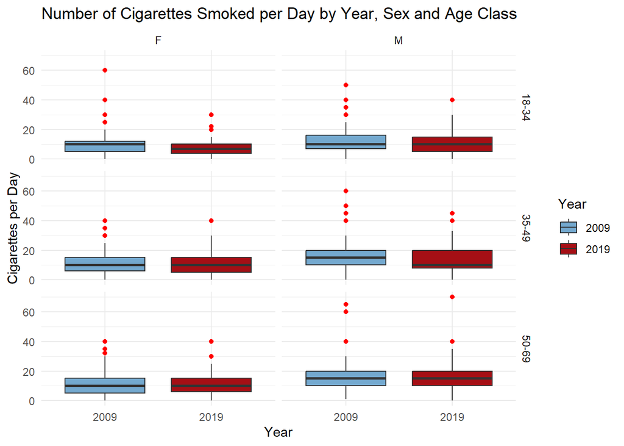

```r
# Since there were some observations with the value -1 ("Less than one cigarette per day") for the variable `s03_fumo_quanto`, we considered them as 0 since a subject either smokes one cigarett or does not smoke at all
Cigarettes_Alcohol$s03_fumo_quanto[Cigarettes_Alcohol$s03_fumo_quanto == -1] = 0

# Boxplot of the number of cigarettes smoked per day among smokers
ggplot(Cigarettes_Alcohol %>% filter(s03_fumo_att == 1, !is.na(s03_fumo_quanto)),
       aes(x = as.factor(anno), y = s03_fumo_quanto, fill = as.factor(anno))) +
  geom_boxplot(outlier.color = "red") +
  facet_grid(claeta3 ~ sesso_intervistato) +
  labs(title = "Number of Cigarettes Smoked per Day by Year, Sex and Age Class", x = "Year", y = "Cigarettes per Day") +
  scale_fill_manual(name = "Year", values = c("2009" = "#74a9cf", "2019" = "#a50f15")) +
  theme_minimal()
```

The boxplot illustrates the distribution of the number of cigarettes smoked per day among current smokers, stratified by year, sex and age classes.  
We can see that:  
• **Gender Differences**: Male smokers higher daily cigarettes consumption than females in the same age group and year. This trend is evident in all three age classes;  
• **Age Differences**: Cigarette consumption increase with age. The 50-69 age group shows the highest median and interquartile ranges, followed by the 35-49 group. The youngest group (18-34) exhibits the lowest values overall. This indicates a clear positive association between age and smoking identity;  
• **Temporal Comparison**: When comparing 2009 to 2019, there appears to be a slight reduction or stabilization in the number of cigarettes smoked per day in some subgroups, though the differences are not substantial. The distribution remain similar across the two years, suggesting no drastic change in smoking intensity during the ten-year span;  
• **Outliers**: Several outliers are visible, especially in the older age groups, indicating that a small subset of smokers report very high daily cigarettes use. These outliers contribute to the overdispersion.  
For the creation of the statistical model, since the variable `s03_fumo_quanto` represents a count (number of cigarettes smoked per day) among smokers (`s03_fumo_att == 1`), it is essential to first analyse the model to be used.  
Since Poisson models assume that:  
**mean = variance**  
It becomes essential then to analyse this equality in such a way as to understand if the variance is greater than the mean (**overdispersion**) or the residual of the Poisson model seem large and poorly distributed. If so, then, the Poisson model is not appropriate and it becomes more correct to use the Negative Binomial.  
We have to confront the two models:

```r
Model_Smoke_Number_Poisson = glm(
  s03_fumo_quanto ~ as.factor(anno) + as.factor(sesso_intervistato) + as.factor(claeta3),
  family = poisson(),
  data = Cigarettes_Alcohol %>% filter(s03_fumo_att == 1, !is.na(s03_fumo_quanto))
)

Model_Smoke_Number_NB = glm.nb(
  s03_fumo_quanto ~ as.factor(anno) + as.factor(sesso_intervistato) + as.factor(claeta3),
  data = Cigarettes_Alcohol %>% filter(s03_fumo_att == 1, !is.na(s03_fumo_quanto))
)
```

```r
# Dispersion Calculation
dispersion = sum(residuals(Model_Smoke_Number_Poisson, type = "pearson")^2) / df.residual(Model_Smoke_Number_Poisson)
dispersion
```

```
## [1] 4.888794
```

```r
# AIC Caluclation
AIC(Model_Smoke_Number_Poisson, Model_Smoke_Number_NB)
```

```
##                            df      AIC
## Model_Smoke_Number_Poisson  5 31492.97
## Model_Smoke_Number_NB       6 23647.30
```

The overdisperion is greater than 1 (**variance > mean**) and the Negative Binomial has a lower AIC.  
So we use the Negative Binomial Model.

```
##
## Call:
## glm.nb(formula = s03_fumo_quanto ~ as.factor(anno) + as.factor(sesso_intervistato) +
##     as.factor(claeta3), data = Cigarettes_Alcohol %>% filter(s03_fumo_att ==
##     1, !is.na(s03_fumo_quanto)), init.theta = 2.858876701, link = log)
##
## Coefficients:
##                                Estimate Std. Error z value Pr(>|z|)
## (Intercept)                     2.21233    0.02541  87.065  < 2e-16 ***
## as.factor(anno)2019            -0.13556    0.02258  -6.004 1.93e-09 ***
## as.factor(sesso_intervistato)M  0.28115    0.02255  12.466  < 2e-16 ***
## as.factor(claeta3)35-49         0.22724    0.02732   8.319  < 2e-16 ***
## as.factor(claeta3)50-69         0.30539    0.02775  11.006  < 2e-16 ***
## ---
## Signif. codes:  0 '***' 0.001 '**' 0.01 '*' 0.05 '.' 0.1 ' ' 1
##
## (Dispersion parameter for Negative Binomial(2.8589) family taken to be 1)
##
##     Null deviance: 4220.1  on 3505  degrees of freedom
## Residual deviance: 3913.8  on 3501  degrees of freedom
## AIC: 23647
##
## Number of Fisher Scoring iterations: 1
##
##
##               Theta:  2.8589
##           Std. Err.:  0.0874
##
##  2 x log-likelihood:  -23635.2950
```

A **Negative Binomial Regression model** was fitted for the number of cigarettes smoked per day among current smokers, appropriate for overdispersed count data. The dependent variables is `s03_fumo_quanto`, and the predictors include `anno`, `sesso_intervistato`, and `claeta3`.  
The model output confirms that all predictors are statistically significant. Specifically:  
• The negative coefficient for `anno == 2019` (**Estimate = -0.13556, p < 0.001**) indicates a significant reduction in the number of cigarettes smoked per day in 2019 compared to 2009;  
• Males have a significant higher cigarettes consumption than females, as shown by the positive coefficient for `sesso_intervistato == M` (**Estimate = 0.28115, p < 0.001**);  
• Age classes also have a significant impact individuals aged **35-49** abd **50-69** smoke more on average than those aged **18-34**, with increasing coefficients by age group.  
These findings are consistent with the boxplot visualization, which displays the distribution of cigarette consumption by year, sex and age class.  
The result provide strong statistical and visual evidence that the cigarette consumption differs significantly by year, gender and age.

## 3.2 Alcohol Consumption

For Alcohol consumption we focus on **how many days did the subject drink at least one unit of alcoholic beverage during the last 30 days** (by *unit of alcoholic beverage* we mean a glass of wine, or a can of beer or a shot of liquor) between the two reference years and between the two sexes.  
Then we analyse how, on drinking days, the **average quantities of units of alcoholic beverages in a day** vary, making a comparison not only between sex and year, but also taking age classes as reference.

### 3.2.1 Alcohol Consumption during the last 30 days

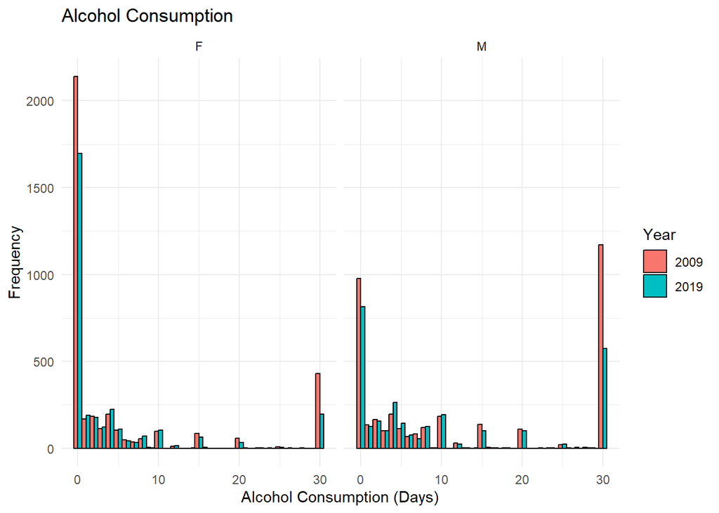

```r
# Histogram of number of days alcohol was consumed in the past 30 days, grouped by year and sex
ggplot(Cigarettes_Alcohol %>% filter(!is.na(s05_alcool_gg)),
       aes(x = s05_alcool_gg, fill = as.factor(anno))) +
  geom_histogram(position = "dodge", binwidth = 1, color = "black") +
  facet_wrap(~ sesso_intervistato) +
  labs(title = "Alcohol Consumption", x = "Alcohol Consumption (Days)", y = "Frequency", fill = "Year") +
  theme_minimal()
```

```r
Model_Alcohol_Days_Poisson = glm(
  Cigarettes_Alcohol$s05_alcool_gg ~ as.factor(Cigarettes_Alcohol$anno) + as.factor(Cigarettes_Alcohol$sesso_intervistato),
  family = poisson(),
  na.action = na.omit
)

Model_Alcohol_Days_NB = glm.nb(
  Cigarettes_Alcohol$s05_alcool_gg ~ as.factor(Cigarettes_Alcohol$anno) + as.factor(Cigarettes_Alcohol$sesso_intervistato),
  na.action = na.omit
)
```

```r
# Dispersion Calculation
dispersion = sum(residuals(Model_Alcohol_Days_Poisson, type = "pearson")^2) / df.residual(Model_Alcohol_Days_Poisson)
dispersion
```

```
## [1] 14.87019
```

```r
# AIC Caluclation
AIC(Model_Alcohol_Days_Poisson, Model_Alcohol_Days_NB)
```

```
##                            df       AIC
## Model_Alcohol_Days_Poisson  3 206521.87
## Model_Alcohol_Days_NB       4  73904.92
```

The overdisperion is greater than 1 (**variance > mean**) and the Negative Binomial has a lower AIC.  
So we use the Negative Binomial Model.

```
##
## Call:
## glm.nb(formula = Cigarettes_Alcohol$s05_alcool_gg ~ as.factor(Cigarettes_Alcohol$anno) +
##     as.factor(Cigarettes_Alcohol$sesso_intervistato), na.action = na.omit,
##     init.theta = 0.3010900975, link = log)
##
## Coefficients:
##                                                   Estimate Std. Error z value
## (Intercept)                                        1.67329    0.02700  61.974
## as.factor(Cigarettes_Alcohol$anno)2019            -0.28276    0.03247  -8.707
## as.factor(Cigarettes_Alcohol$sesso_intervistato)M  0.88252    0.03227  27.349
##                                                   Pr(>|z|)
## (Intercept)                                         <2e-16 ***
## as.factor(Cigarettes_Alcohol$anno)2019              <2e-16 ***
## as.factor(Cigarettes_Alcohol$sesso_intervistato)M   <2e-16 ***
## ---
## Signif. codes:  0 '***' 0.001 '**' 0.01 '*' 0.05 '.' 0.1 ' ' 1
##
## (Dispersion parameter for Negative Binomial(0.3011) family taken to be 1)
##
##     Null deviance: 14319  on 13343  degrees of freedom
## Residual deviance: 13508  on 13341  degrees of freedom
##   (246 osservazioni eliminate a causa di valori mancanti)
## AIC: 73905
##
## Number of Fisher Scoring iterations: 1
##
##
##               Theta:  0.30109
##           Std. Err.:  0.00449
##
##  2 x log-likelihood:  -73896.91800
```

A **Negative Binomial Regression model** was fitted using the number of days alcohol was consumed in the past 30 days(`s05_alcoo_gg`) as the outcome variable. The predictors included `anno` and `sesso_intervistato`, both treated as categorical variables.  
The regression results indicate the following:  
• The **intercept** (Estimate = 1.67329) represents the log-mean number of alcohol consumption days in 2009 among females;  
• The coefficient for `anno == 2019` is **negative and statistically significant** (Estimate = -0.28276, p < 0.001), suggesting that, holding sex constant, alcohol consumption significantly **decreased** in 2019 compared to 2009;  
• The coefficient for `sesso_intervistato == M` is **positive and highly significant** (Estimate = 0.88252, p < 0.001), indicating that men consume alcohol on significantly more days than women.  
These findings are visually supported by the histogram above.  
In conclusion, the model provides strong statistical evidence of a **significant reduction in alcohol consumption over time**, as well as **clear gender differences**, with males consuming alcohol more frequently than females. These results are reinforced by the graphical distribution, supporting the robustness of the model’s conclusion.

### 3.2.2 Units of Alcoholic beverages on drinking days

The plot below is a **combined violin and boxplot** and it was chosen because, in addition to all the features of the boxplot, the violin shape provides a smoothed density estimate of the data, allowing us to visualize asymmetries, skewness and multimodality within each group.

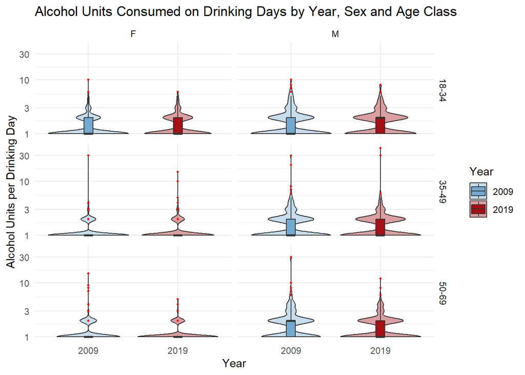

```r
# Boxplot of alcohol units consumed on drinking days, stratified by year, sex and age class
ggplot(Cigarettes_Alcohol %>% filter(!is.na(s05_alcool_quanto)),
       aes(x = as.factor(anno), y = s05_alcool_quanto, fill = as.factor(anno))) +
  geom_violin(alpha = 0.4, trim = TRUE) +
  geom_boxplot(width = 0.1, outlier.size = 0.8, outlier.color = "red") +
  facet_grid(claeta3 ~ sesso_intervistato) +
  scale_y_log10() +
  labs(title = "Alcohol Units Consumed on Drinking Days by Year, Sex and Age Class", x = "Year", y = "Alcohol Units per Drinking Day") +
  scale_fill_manual(name = "Year", values = c("2009" = "#74a9cf", "2019" = "#a50f15"))+
  theme_minimal()
```

```r
Model_Alcohol_Quantity_Poisson = glm(
  Cigarettes_Alcohol$s05_alcool_quanto ~ as.factor(Cigarettes_Alcohol$anno) + as.factor(Cigarettes_Alcohol$sesso_intervistato) + as.factor(Cigarettes_Alcohol$claeta3),
  family = poisson(),
  Cigarettes_Alcohol %>% filter(!is.na(s05_alcool_quanto), s05_alcool_quanto > 0)
)

Model_Alcohol_Quantity_NB = glm.nb(
  Cigarettes_Alcohol$s05_alcool_quanto ~ as.factor(Cigarettes_Alcohol$anno) + as.factor(Cigarettes_Alcohol$sesso_intervistato) + as.factor(Cigarettes_Alcohol$claeta3),
  Cigarettes_Alcohol %>% filter(!is.na(s05_alcool_quanto), s05_alcool_quanto > 0)
)
```

```r
# Dispersion Calculation
dispersion = sum(residuals(Model_Alcohol_Quantity_Poisson, type = "pearson")^2) / df.residual(Model_Alcohol_Quantity_Poisson)
dispersion
```

```
## [1] 1.23524
```

```r
# AIC Calculation
AIC(Model_Alcohol_Quantity_Poisson, Model_Alcohol_Quantity_NB)
```

```
##                                df      AIC
## Model_Alcohol_Quantity_Poisson  5 21947.49
## Model_Alcohol_Quantity_NB       6 21908.78
```

The overdisperion is a little bigger than 1 (**variance > mean**) and the Negative Binomial has an AIC slightly lower than the Poisson.  
So we use the Negative Binomial Model.

```
##
## Call:
## glm.nb(formula = Cigarettes_Alcohol$s05_alcool_quanto ~ as.factor(Cigarettes_Alcohol$anno) +
##     as.factor(Cigarettes_Alcohol$sesso_intervistato) + as.factor(Cigarettes_Alcohol$claeta3),
##     data = Cigarettes_Alcohol %>% filter(!is.na(s05_alcool_quanto),
##         s05_alcool_quanto > 0), init.theta = 37.84855194, link = log)
##
## Coefficients:
##                                                   Estimate Std. Error z value
## (Intercept)                                        0.33456    0.02272  14.725
## as.factor(Cigarettes_Alcohol$anno)2019            -0.06418    0.01868  -3.435
## as.factor(Cigarettes_Alcohol$sesso_intervistato)M  0.29509    0.01979  14.914
## as.factor(Cigarettes_Alcohol$claeta3)35-49        -0.06154    0.02347  -2.622
## as.factor(Cigarettes_Alcohol$claeta3)50-69        -0.02442    0.02261  -1.080
##                                                   Pr(>|z|)
## (Intercept)                                        < 2e-16 ***
## as.factor(Cigarettes_Alcohol$anno)2019            0.000593 ***
## as.factor(Cigarettes_Alcohol$sesso_intervistato)M  < 2e-16 ***
## as.factor(Cigarettes_Alcohol$claeta3)35-49        0.008749 **
## as.factor(Cigarettes_Alcohol$claeta3)50-69        0.280027
## ---
## Signif. codes:  0 '***' 0.001 '**' 0.01 '*' 0.05 '.' 0.1 ' ' 1
##
## (Dispersion parameter for Negative Binomial(37.8486) family taken to be 1)
##
##     Null deviance: 4320.0  on 7642  degrees of freedom
## Residual deviance: 4070.8  on 7638  degrees of freedom
##   (5947 osservazioni eliminate a causa di valori mancanti)
## AIC: 21909
##
## Number of Fisher Scoring iterations: 1
##
##
##               Theta:  37.85
##           Std. Err.:  6.83
##
##  2 x log-likelihood:  -21896.78
```

## 3.3 Cardiovascular Risk

For the Cardiovascular risk, before going to understand how and if smoking and alcohol can impact, it is interesting to analyse cardiovascular risk not only among the reference variables (sex, year and age classes), but also at the territorial level with regards to **regions** and **ASL**.

### 3.3.1 Cardiovascular Risk in the population

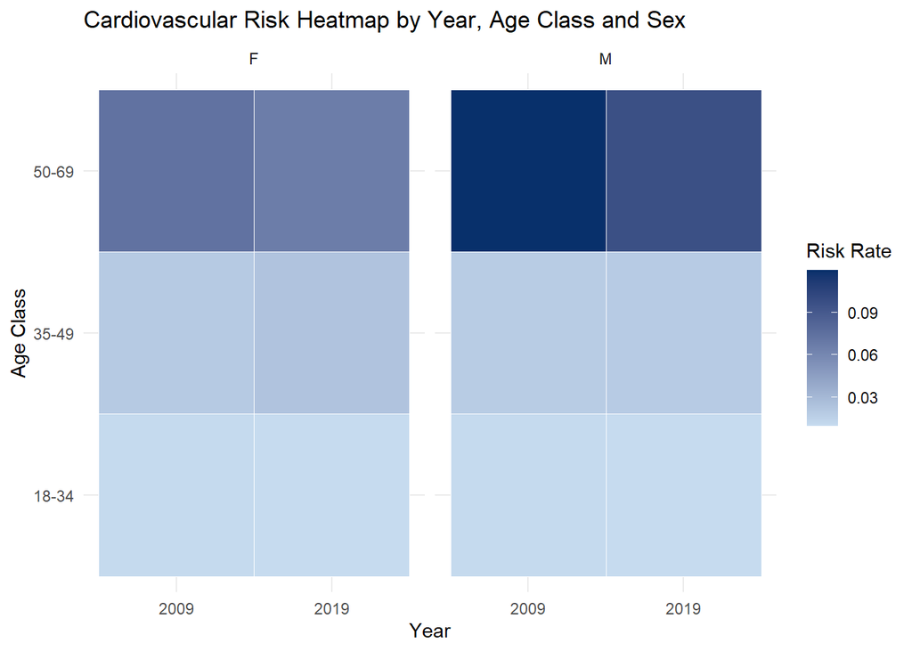

```r
# Heatmap for cardiovascular risk
ggplot(heatmap_cardiovasc, aes(x = anno, y = claeta3, fill = risk_rate))+
  geom_tile(color = "white") +
  facet_wrap(~ sesso_intervistato)+
  scale_fill_gradient(low = "#c6dbef", high = "#08306b", name = "Risk Rate") +
  labs(title = "Cardiovascular Risk Heatmap by Year, Age Class and Sex", x = "Year", y = "Age Class") +
  theme_minimal()
```

```r
# Logistic regression model for cardiovascular risk calculation
Model_Calc_Risk = glm(Cigarettes_Alcohol$cardiovasc ~ as.factor(Cigarettes_Alcohol$anno) +
                        as.factor(Cigarettes_Alcohol$sesso_intervistato) +
                        as.factor(Cigarettes_Alcohol$claeta3),
                      family = binomial,
                      na.action = na.omit)
summary(Model_Calc_Risk)
```

```
##
## Call:
## glm(formula = Cigarettes_Alcohol$cardiovasc ~ as.factor(Cigarettes_Alcohol$anno) +
##     as.factor(Cigarettes_Alcohol$sesso_intervistato) + as.factor(Cigarettes_Alcohol$claeta3),
##     family = binomial, na.action = na.omit)
##
## Coefficients:
##                                                   Estimate Std. Error z value
## (Intercept)                                       -4.69652    0.17398 -26.994
## as.factor(Cigarettes_Alcohol$anno)2019            -0.12744    0.08513  -1.497
## as.factor(Cigarettes_Alcohol$sesso_intervistato)M  0.34772    0.08505   4.088
## as.factor(Cigarettes_Alcohol$claeta3)35-49         0.68330    0.19417   3.519
## as.factor(Cigarettes_Alcohol$claeta3)50-69         2.24988    0.17009  13.228
##                                                   Pr(>|z|)
## (Intercept)                                        < 2e-16 ***
## as.factor(Cigarettes_Alcohol$anno)2019            0.134413
## as.factor(Cigarettes_Alcohol$sesso_intervistato)M 4.34e-05 ***
## as.factor(Cigarettes_Alcohol$claeta3)35-49        0.000433 ***
## as.factor(Cigarettes_Alcohol$claeta3)50-69         < 2e-16 ***
## ---
## Signif. codes:  0 '***' 0.001 '**' 0.01 '*' 0.05 '.' 0.1 ' ' 1
##
## (Dispersion parameter for binomial family taken to be 1)
##
##     Null deviance: 4960.0  on 13586  degrees of freedom
## Residual deviance: 4521.7  on 13582  degrees of freedom
##   (3 osservazioni eliminate a causa di valori mancanti)
## AIC: 4531.7
##
## Number of Fisher Scoring iterations: 7
```

### 3.3.2 Cardiovascular Risk by Regions and ASL

For the analysis of cardiovascular risk at territorial level, for the **regions** we created a map of Italy, while for the **ASL** we selected only the **15 ASL** with the highest cardiovascular risk cases.

```r
# Download Italian regional boundaries (level 1 = regions)
# This loads official administrative boundaries directly into R
Cigarettes_Alcohol_copy = Cigarettes_Alcohol
# Since Trentino and Alto Adige were indicated as two separate regions in the PASSI, to create the map we created a copy of the dataset in which we identified the two regions in a single region (Trentino-Alto Adige)
Cigarettes_Alcohol_copy$regione = ifelse(Cigarettes_Alcohol_copy$regione %in% c("Trentino", "Alto Adige"), "Trentino-Alto Adige", Cigarettes_Alcohol_copy$regione)

italy_regions = geodata::gadm(country = "ITA", level = 1, path = tempdir())
italy_regions = st_as_sf(italy_regions)
# Prepare cardiovascular risk data by region and year
# Replace 'regione' with the actual column name in the dataset for region
cardio_2009 = Cigarettes_Alcohol_copy %>%
  filter(anno == 2009, !is.na(cardiovasc)) %>%
  group_by(regione) %>%
  summarise(risk_rate_2009 = mean(cardiovasc == 1))
cardio_2019 = Cigarettes_Alcohol_copy %>%
  filter(anno == 2019, !is.na(cardiovasc)) %>%
  group_by(regione) %>%
  summarise(risk_rate_2019 = mean(cardiovasc == 1))
# Match and join spatial and statistical data
# Change of some names of the regions that were different
italy_regions$NAME_1[italy_regions$NAME_1 == "Valle d'Aosta"] = "Valle D'Aosta"
italy_regions$NAME_1[italy_regions$NAME_1 == "Apulia"] = "Puglia"
italy_regions$NAME_1[italy_regions$NAME_1 == "Sicily"] = "Sicilia"
italy_regions$NAME_1[italy_regions$NAME_1 == "Friuli-Venezia Giulia"] = "Friuli Venezia Giulia"

italy_map_2009 = italy_regions %>% left_join(cardio_2009, by = c("NAME_1" = "regione"))
italy_map_2019 = italy_regions %>% left_join(cardio_2019, by = c("NAME_1" = "regione"))
```

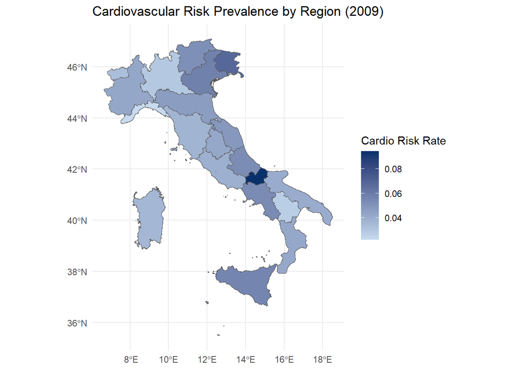

```r
# 2009 Year
ggplot(data = italy_map_2009) +
  geom_sf(aes(fill = risk_rate_2009)) +
  scale_fill_gradient(low = "#c6dbef", high = "#08306b", name = "Cardio Risk Rate", na.value = "grey90") +
  labs(title = "Cardiovascular Risk Prevalence by Region (2009)") +
  theme_minimal()
```

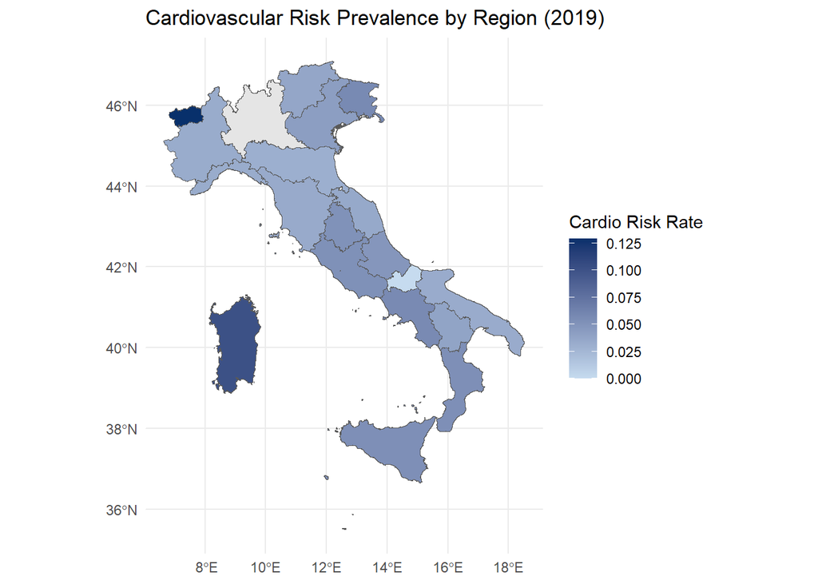

```r
# 2019 Year
ggplot(data = italy_map_2019) +
  geom_sf(aes(fill = risk_rate_2019)) +
  scale_fill_gradient(low = "#c6dbef", high = "#08306b", name = "Cardio Risk Rate", na.value = "grey90") +
  labs(title = "Cardiovascular Risk Prevalence by Region (2019)") +
  theme_minimal()
```

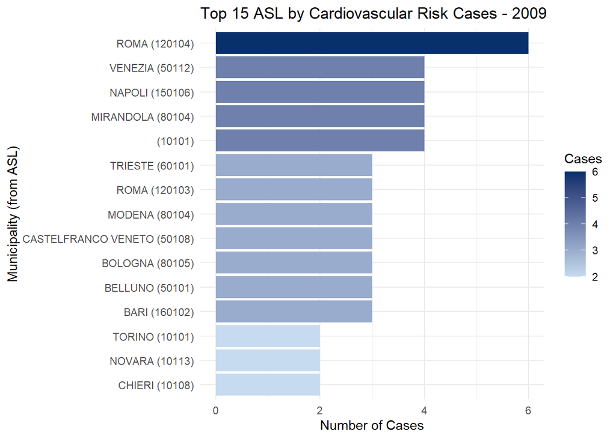

```r
# 2009 Year
ggplot(Cigarettes_Alcohol %>% filter(anno == 2009, cardiovasc == 1) %>%
         group_by(asl, comune_intervistato) %>%
         summarise(cases = n(), comune_label = first(comune_intervistato), .groups = "drop") %>%
         arrange(desc(cases)) %>%
         slice_head(n = 15),
       aes(x = reorder(paste0(comune_label, " (", asl, ")"), cases), y = cases, fill = cases)) +
  geom_bar(stat = "identity") +
  coord_flip() +
  scale_fill_gradient(low = "#c6dbef", high = "#08306b") +
  labs(title = "Top 15 ASL by Cardiovascular Risk Cases - 2009", x = "Municipality (from ASL)", y = "Number of Cases", fill = "Cases") +
  theme_minimal()
```

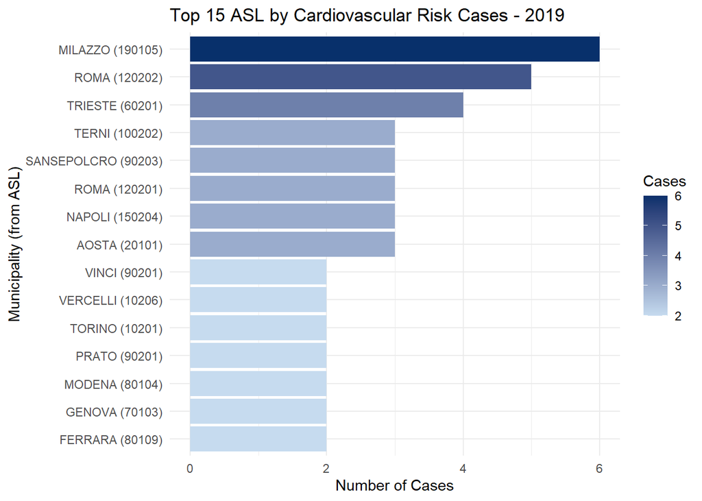

```r
# 2019 Year
ggplot(Cigarettes_Alcohol %>% filter(anno == 2019, cardiovasc == 1) %>%
         group_by(asl, comune_intervistato) %>%
         summarise(cases = n(), comune_label = first(comune_intervistato), .groups = "drop") %>%
         arrange(desc(cases)) %>%
         slice_head(n = 15),
       aes(x = reorder(paste0(comune_label, " (", asl, ")"), cases), y = cases, fill = cases)) +
  geom_bar(stat = "identity") +
  coord_flip() +
  scale_fill_gradient(low = "#c6dbef", high = "#08306b") +
  labs(title = "Top 15 ASL by Cardiovascular Risk Cases - 2019", x = "Municipality (from ASL)", y = "Number of Cases", fill = "Cases") +
  theme_minimal()
```

In 2009, the highest regional cardiovascular risk is concentrated in **Molise**, clearly visible through the darkest shade on the map. Other regions such as **Campania**, **Sicilia** and some areas in the **north-east** (e.g. Friuli-Venezia Giulia) also show moderately elevated risk levels.  
By contrast, in 2019, the regional pattern changes notably. **Sardinia** and **Valle d’Aosta** emerge as the regions with the highest risk prevalence, while other regions that had higher risk in 2009 - like Molise - exhibit lighter shades, suggesting a relative decline in risk. This suggest a **geographic shift** in cardiovascular risk between the two years, from **central-southern** Italy in 2009 to **more peripheral regions** (e.g. islands and Alpine regions) in 2019.  
However, regional data can sometimes mask local dynamics, which is why the ASL-level plots are essential for a more granular view.  
In 2009, the bar chart shows that **Rome (ASL 120104)** recorded the highest number of cardiovascular cases, followed by ASLs in **Venice**, **Naples**, **Mirandola** and **Trieste**, highlighting large urban centers and some Northern municipalities as hotspots.  
In 2019, while **Rome** remains prominent, it is **Milazzo (ASL 190105)** that tops the chart, followed by ASLs in **Trieste**, **Terni**, **Sansepolcro** and **Aosta**. These results indicate a broader dispersion of cardiovascular risk cases, including mid-sized and smaller municipalities in 2019 compared to a more urban-centric distribution in 2009.  
Overall, the combined regional and ASL analyses provide a **comprehensive territorial perspective**, suggesting that public health policies should be tailored both regionally and locally, taking into account the **emergence of new high-risk areas**.

## 3.4 Impact of Cigarettes and Alcohol

For the final part of this chapter, after having individually analysed risk factor such as smoking and alcohol, and after having analysed cardiovascular risk at a territorial level, it is important to focus on how the factors just mentioned influence cardiovascular risk, thus understanding, from a statistical point of view, whether they are significant or no.  
We fitted a **Generalized Linear Mixed Model (GLMM)** using the `glmer()` function and with the following fixed effects:  
• Smoking status (`s03_fumo_att`) and year(`anno`), along with their interaction, to assess how the effect of smoking on cardiovascular risk changes over time;  
• Alcohol consumption (`s05_alcool_gg`) and its interaction with year, to evaluate temporal changes in the impact of alcohol use;  
• Sex (`sesso_intervistato`) and age class (`claeta3`) as demographic covariates that may could influence cardiovascular risk. The model also includes a random intercept for region or ASL (*We need to see which of the two variables is more significant*), in order to capture the hierarchical structure of the data.  
Moreover, the model uses the `"bobyqa" optimizer` to ensure convergence, which is often necessary for complex models with random effects.  
In summary, this is a multilevel logistic regression model that estimates the impact of lifestyle factors (smoking and alcohol use), demographic (sex and age), and temporal change (year) on cardiovascular risk.

```r
# Model with ASL as random intercept
Model_Card_ASL = glmer(cardiovasc ~
                    as.factor(s03_fumo_att) * as.factor(anno) +
                    s05_alcool_gg * as.factor(anno)+
                    as.factor(sesso_intervistato) +
                    as.factor(claeta3) +
                    (1 | asl),
                  data = Cigarettes_Alcohol,
                  family = binomial,
                  control = glmerControl(optimizer = "bobyqa"))

# Model with Region as random intercept
Model_Card_Regione = glmer(cardiovasc ~
                    as.factor(s03_fumo_att) * as.factor(anno) +
                    s05_alcool_gg * as.factor(anno)+
                    as.factor(sesso_intervistato) +
                    as.factor(claeta3) +
                    (1 | regione),
                  data = Cigarettes_Alcohol,
                  family = binomial,
                  control = glmerControl(optimizer = "bobyqa"))

# Let's compare the two models
anova(Model_Card_ASL, Model_Card_Regione)
```

```
## Data: Cigarettes_Alcohol
## Models:
## Model_Card_ASL: cardiovasc ~ as.factor(s03_fumo_att) * as.factor(anno) + s05_alcool_gg * as.factor(anno) + as.factor(sesso_intervistato) + as.factor(claeta3) + (1 | asl)
## Model_Card_Regione: cardiovasc ~ as.factor(s03_fumo_att) * as.factor(anno) + s05_alcool_gg * as.factor(anno) + as.factor(sesso_intervistato) + as.factor(claeta3) + (1 | regione)
##                    npar    AIC    BIC  logLik -2*log(L)  Chisq Df Pr(>Chisq)
## Model_Card_ASL       10 2425.9 2493.2 -1202.9    2405.9
## Model_Card_Regione   10 2423.7 2491.0 -1201.8    2403.7 2.1892  0
```

Although both models present very similar values (comparing AIC and BIC), the one with region as a random effect captures the structure of the data better than the one based on ASL.

```r
parameters::random_parameters(Model_Card_ASL)
```

```
## # Random Effects
##
## Within-Group Variance     3.29 (1.81)
## Between-Group Variance
##   Random Intercept (asl)  0.08 (0.28)
## N (groups per factor)
##   asl                      209
## Observations              6178
```

```r
parameters::random_parameters(Model_Card_Regione)
```

```
## # Random Effects
##
## Within-Group Variance         3.29 (1.81)
## Between-Group Variance
##   Random Intercept (regione)  0.04 (0.21)
## N (groups per factor)
##   regione                       21
## Observations                  6178
```

```
## Generalized linear mixed model fit by maximum likelihood (Laplace
##   Approximation) [glmerMod]
##  Family: binomial  ( logit )
## Formula:
## cardiovasc ~ as.factor(s03_fumo_att) * as.factor(anno) + s05_alcool_gg *
##     as.factor(anno) + as.factor(sesso_intervistato) + as.factor(claeta3) +
##     (1 | regione)
##    Data: Cigarettes_Alcohol
## Control: glmerControl(optimizer = "bobyqa")
##
##       AIC       BIC    logLik -2*log(L)  df.resid
##    2423.7    2491.0   -1201.8    2403.7      6168
##
## Scaled residuals:
##     Min      1Q  Median      3Q     Max
## -0.4777 -0.2926 -0.1758 -0.1170 12.8731
##
## Random effects:
##  Groups  Name        Variance Std.Dev.
##  regione (Intercept) 0.0435   0.2086
## Number of obs: 6178, groups:  regione, 21
##
## Fixed effects:
##                                               Estimate Std. Error z value
## (Intercept)                                  -4.064944   0.276784 -14.686
## as.factor(s03_fumo_att)1                     -0.876969   0.171099  -5.125
## as.factor(anno)2019                           0.035602   0.174057   0.205
## s05_alcool_gg                                -0.002641   0.005924  -0.446
## as.factor(sesso_intervistato)M                0.306223   0.125360   2.443
## as.factor(claeta3)35-49                       0.733750   0.273961   2.678
## as.factor(claeta3)50-69                       2.047800   0.249195   8.218
## as.factor(s03_fumo_att)1:as.factor(anno)2019  0.324744   0.241177   1.346
## as.factor(anno)2019:s05_alcool_gg            -0.004570   0.009085  -0.503
##                                              Pr(>|z|)
## (Intercept)                                   < 2e-16 ***
## as.factor(s03_fumo_att)1                     2.97e-07 ***
## as.factor(anno)2019                            0.8379
## s05_alcool_gg                                  0.6558
## as.factor(sesso_intervistato)M                 0.0146 *
## as.factor(claeta3)35-49                        0.0074 **
## as.factor(claeta3)50-69                       < 2e-16 ***
## as.factor(s03_fumo_att)1:as.factor(anno)2019   0.1781
## as.factor(anno)2019:s05_alcool_gg              0.6149
## ---
## Signif. codes:  0 '***' 0.001 '**' 0.01 '*' 0.05 '.' 0.1 ' ' 1
##
## Correlation of Fixed Effects:
##             (Intr) as.(03__)1 as.()2019 s05_l_ a.(_)M a.(3)3 a.(3)5 a.(03__)1:
## as.f(03__)1 -0.297
## as.fc()2019 -0.283  0.299
## s05_alcl_gg -0.155  0.013      0.420
## as.fctr(_)M -0.264  0.069      0.017    -0.225
## as.(3)35-49 -0.753  0.055     -0.014    -0.030  0.006
## as.(3)50-69 -0.834  0.112     -0.025    -0.065  0.001  0.836
## a.(03__)1:.  0.152 -0.696     -0.492    -0.021 -0.033 -0.005 -0.015
## a.()2019:05  0.167 -0.026     -0.579    -0.614 -0.002  0.006  0.009  0.036
```

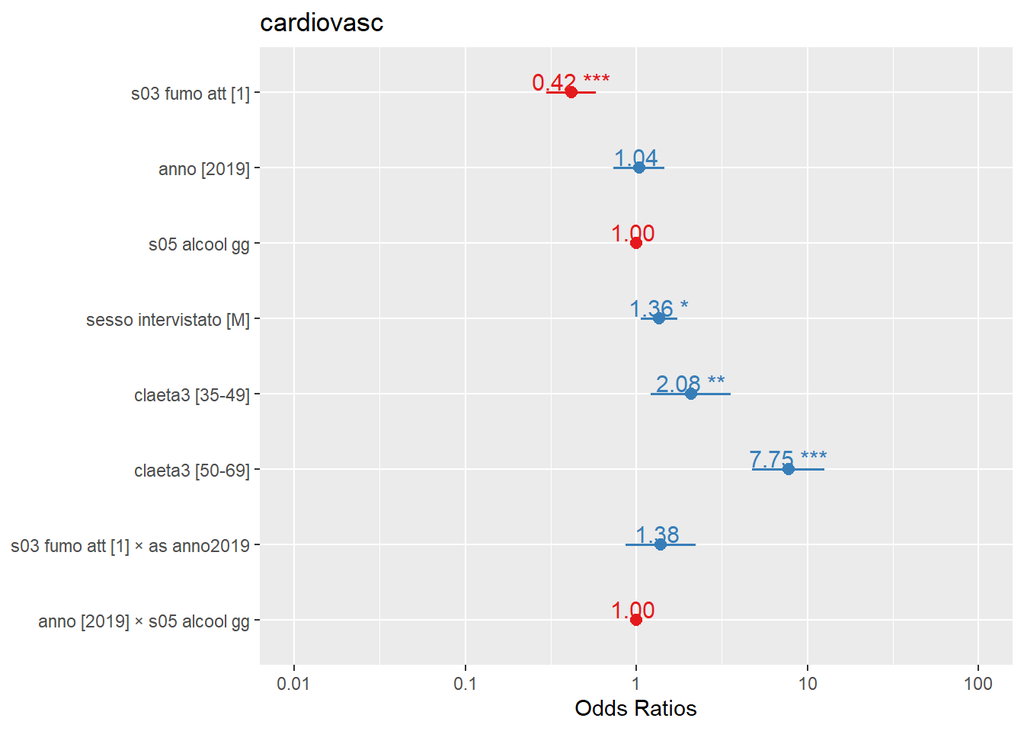

Looking at the statistical model output and the related graph what we can basically say is that the variables that are most significant with regard to cardiovascular risk are, mainly the **age classes** (as seen previously in previous models): individuals aged 35-49 have higher odds of cardiovascular risk (Estimate = 0.733787, p = 0.0074), with about twice the probability of having cardiovascular risk compared to younger people; those aged 50-69 have the highest risk (Estimate = 2.047836, p < 0.001), confirming the expected age-related increase in cardiovascular vulnerability with a 675% higher probability, so almost 8 times as much.
Interaction between smoking and year is not statistically significant (p = 0.1787), suggesting that the effect of smoking on cardiovascular risk did not differ meaningfully between 2009 and 2019. Similarly, the interaction between alcohol and year is also not significant (p = 0.6149), implying a stable effect over time.
But what is most surprising, as we can observe in the model output and also in the graph, is the fact that the two factors we were interested in (smoking and alcohol) **do not seem to be significant** for cardiovascular risk.
Specifically, as regards **alcohol consumption**, the latter does not appear significant (Estimate = -0.002640, p = 0.6558). However, reasoning, this result may make sense, since if a subject is in an optimal state of health then he or she will be more likely to consume alcohol, while a subject who has been notified by a doctor of a cardiovascular risk **will be less likely to drink**, knowing that in general alcoholic beverages are dangerous to health, particularly to the cardiovascular system.
For **cigarettes**, however the result creates a bit of confusion, since the variables is significant (p < 0.001), but it seems that non-smokers have a higher cardiovascular risk (Estimate = -0.876952), while smokers have a lower cardiovascular risk. Specifically, smokers had an approximately 58% lower probability of having cardiovascular risk compared to non-smokers. For this case there can be two interpretations: the first is based on the same reasoning used above for alcohol consumption (i.e. that if a subject tends to smoke it is because he or she is in good health or has never been notified of a cardiovascular risk), the second can be an interpretation on the variable subject to analysis.
The variable we used for smoking status is `s03_fumo_att`, which answers the following question: *Do you currently smoke cigarettes?* However, this question only considers the present, but does not take into account the fact that a subject may have **been a smoker in the past** and currently does not smoke. To better understand, therefore, whether smoking actually impacts cardiovascular risk or not, we must also consider a subject’s past, analysing the variables `s03_fumo`:
$$\text{s03_fumo}_i =
\begin{cases}
1 & \text{if the subject, in his entire life, has smoked at least
100 cigarettes in total (5 packs of 20 sigarettes)} \\
0 & \text{if the subject has never smoked them}
\end{cases}$$

```r
chisq.test(table(Cigarettes_Alcohol$s03_fumo, Cigarettes_Alcohol$cardiovasc))
```

```
##
##  Pearson's Chi-squared test with Yates' continuity correction
##
## data:  table(Cigarettes_Alcohol$s03_fumo, Cigarettes_Alcohol$cardiovasc)
## X-squared = 32.353, df = 1, p-value = 1.286e-08
```

The chi-square test indicates a statistically significant association between smoking history and cardiovascular risk (X-squared = 32.353, p < 0.001), suggesting that smoking history appears to be linked to an increased likelihood of cardiovascular issues. Let’s fit a statistical model in order to see if it is actually true.

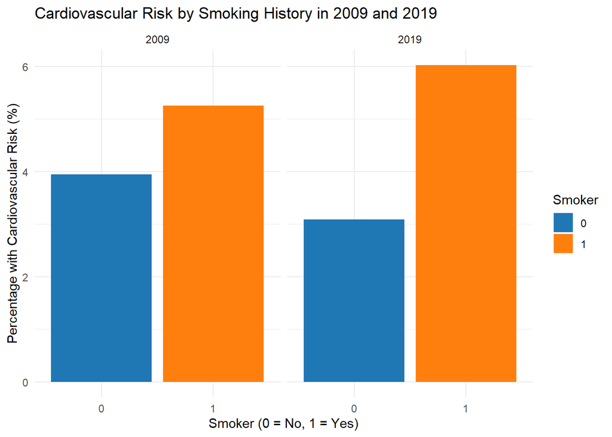

```r
# Bar chart for Cardiovascular risk by Smoking history
ggplot(Cigarettes_Alcohol %>% filter(!is.na(s03_fumo), !is.na(cardiovasc)) %>% group_by(anno, s03_fumo) %>% summarise(risk_rate = mean(cardiovasc == 1)*100, .groups = "drop"),
       aes(x = as.factor(s03_fumo), y = risk_rate, fill = as.factor(s03_fumo))) +
  geom_bar(stat = "identity") +
  facet_wrap(~ anno) +
  scale_fill_manual(values = c("0" = "#1f77b4", "1" = "#ff7f0e")) +
  labs(title = "Cardiovascular Risk by Smoking History in 2009 and 2019", x = "Smoker (0 = No, 1 = Yes)", y = "Percentage with Cardiovascular Risk (%)", fill = "Smoker") +
  theme_minimal()
```

```r
# Generalized Linear Mixed Model with smoking history
Model_Card_Regione_2 = glmer(cardiovasc ~
                    as.factor(s03_fumo) * as.factor(anno) +
                    s05_alcool_gg * as.factor(anno)+
                    as.factor(sesso_intervistato) +
                    as.factor(claeta3) +
                    (1 | regione),
                  data = Cigarettes_Alcohol,
                  family = binomial,
                  control = glmerControl(optimizer = "bobyqa"))
summary(Model_Card_Regione_2)
```

```
## Generalized linear mixed model fit by maximum likelihood (Laplace
##   Approximation) [glmerMod]
##  Family: binomial  ( logit )
## Formula: cardiovasc ~ as.factor(s03_fumo) * as.factor(anno) + s05_alcool_gg *
##     as.factor(anno) + as.factor(sesso_intervistato) + as.factor(claeta3) +
##     (1 | regione)
##    Data: Cigarettes_Alcohol
## Control: glmerControl(optimizer = "bobyqa")
##
##       AIC       BIC    logLik -2*log(L)  df.resid
##    4469.1    4544.1   -2224.6    4449.1     13300
##
## Scaled residuals:
##     Min      1Q  Median      3Q     Max
## -0.4300 -0.2819 -0.1472 -0.1091 13.3617
##
## Random effects:
##  Groups  Name        Variance Std.Dev.
##  regione (Intercept) 0.02825  0.1681
## Number of obs: 13310, groups:  regione, 21
##
## Fixed effects:
##                                           Estimate Std. Error z value Pr(>|z|)
## (Intercept)                              -4.720553   0.189207 -24.949  < 2e-16
## as.factor(s03_fumo)1                      0.128320   0.117153   1.095 0.273378
## as.factor(anno)2019                      -0.317521   0.140117  -2.266 0.023445
## s05_alcool_gg                            -0.002826   0.004564  -0.619 0.535825
## as.factor(sesso_intervistato)M            0.323135   0.091256   3.541 0.000399
## as.factor(claeta3)35-49                   0.703422   0.196111   3.587 0.000335
## as.factor(claeta3)50-69                   2.266789   0.173045  13.099  < 2e-16
## as.factor(s03_fumo)1:as.factor(anno)2019  0.454884   0.175601   2.590 0.009585
## as.factor(anno)2019:s05_alcool_gg        -0.005931   0.007323  -0.810 0.418016
##
## (Intercept)                              ***
## as.factor(s03_fumo)1
## as.factor(anno)2019                      *
## s05_alcool_gg
## as.factor(sesso_intervistato)M           ***
## as.factor(claeta3)35-49                  ***
## as.factor(claeta3)50-69                  ***
## as.factor(s03_fumo)1:as.factor(anno)2019 **
## as.factor(anno)2019:s05_alcool_gg
## ---
## Signif. codes:  0 '***' 0.001 '**' 0.01 '*' 0.05 '.' 0.1 ' ' 1
##
## Correlation of Fixed Effects:
##             (Intr) as.(03_)1 as.()2019 s05_l_ a.(_)M a.(3)3 a.(3)5 a.(03_)1:
## as.fc(03_)1 -0.249
## as.fc()2019 -0.301  0.394
## s05_alcl_gg -0.092 -0.135     0.259
## as.fctr(_)M -0.197 -0.148    -0.028    -0.219
## as.(3)35-49 -0.732 -0.004     0.000    -0.036  0.019
## as.(3)50-69 -0.820 -0.022    -0.028    -0.078  0.045  0.809
## a.(03_)1:.(  0.192 -0.655    -0.638     0.107  0.022 -0.011 -0.001
## a.()2019:05  0.111  0.108    -0.341    -0.584 -0.016  0.009  0.011 -0.168
```

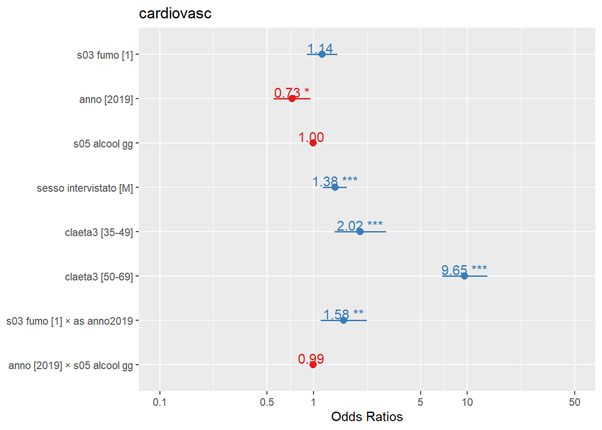

```r
# Plot the results
sjPlot::plot_model(Model_Card_Regione_2, show.values = TRUE,show.p=TRUE)
```

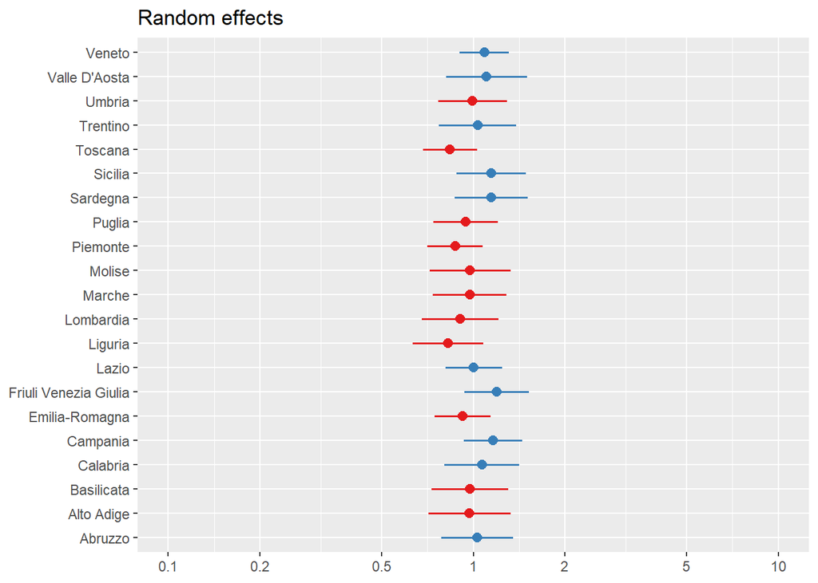

```r
sjPlot::plot_model(Model_Card_Regione_2, type = "re")
```

This statistical model is like the older one but we use `s03_fumo` instead of `s03_fumo_att`.  
If we look at the output this time we can see that **the interaction between smoking status and year 2019 is statistically significant** (p-value = 0.009570), indicating that in 2019 smokers have a 58% higher cardiovascular risk than non-smokers. This suggests that the effect of smoking on cardiovascular risk has changed between 2009 and 2019. Specifically, in 2019, being a smoker significantly increased the probability of having a cardiovascular condition, more than in 2009. However, the main effect of smoking (`s03_fumo`) is not statistically significant (p = 0.273456), suggesting that smoking alone, in the reference year (2009), is not associated with a significantly higher cardiovascular risk.  
This result align with the **bar plot**, which visually shows that in both years, smokers exhibit a higher percentage of cardiovascular risk compared to non-smokers, with a more notable gap in 2019.  
The main effect of alcohol consumption is still not significant, while age classes (35-49 and 50-69) and male gender both still remain strong positive predictors of cardiovascular risk.  
In conclusion, although smoking was not a significant predictor of cardiovascular risk in 2009, its impact became statistically significant in 2019, playing a significant role in cardiovascular risk, with the effect being moderated by demographic and behavioral covariates.  
Public health interventions targeting smoking-related cardiovascular risk may need to be more emphasized in recent years, particularly given the strengthening of this association over time.  
However, in recent years we have increasingly seen government actions aimed to reducing smoking habits, especially among young people who are starting to smoke at an increasingly earlier age. We can cite, for example, the various increases in excise duties on tobacco. In 2022, the average price of a pack of cigarettes increased by 17-18% compared to 2015 (from around €4,50 to over €6,20). However, with the 2025 Italy Budget Law, excise duties on tobacco were further increased, which will lead to an increase in average prices of around 20/30 cents per pack.

# 4 Hypertension Conditions related to Physical Activity

This part examines the changes in intense and moderate physical activity, as well as the prevalence of hypertension conditions in Italy in the years 2009 and 2019, highlighting the most significant differences between the two periods.

## 4.1 Intense Physical Analysis

### 4.1.1 Regional distribution of Intense Physical Activity

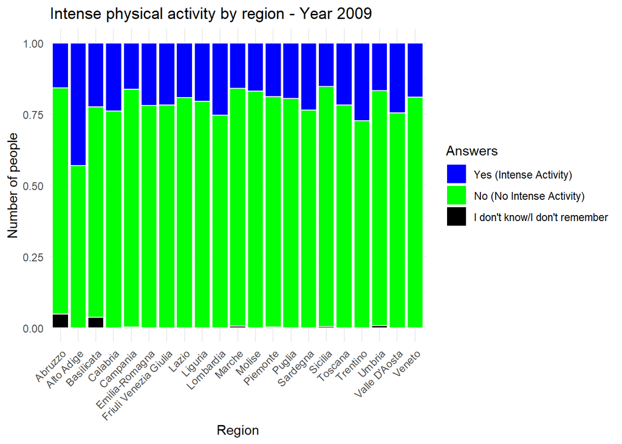

```r
# Filter for valid physical intense activity
dataset_att_intens_year_reg = dataset_definitivo[!is.na(dataset_definitivo$s02_tlib_attiv_inte) &
                                                    dataset_definitivo$s02_tlib_attiv_inte %in% c(1, 2, -99) &
                                                    !is.na(dataset_definitivo$anno) &
                                                    !is.na(dataset_definitivo$regione),
                                                  c("s02_tlib_attiv_inte", "anno", "regione")]

# Add factor labels
dataset_att_intens_year_reg$attivita_label = factor(dataset_att_intens_year_reg$s02_tlib_attiv_inte,
                                                     levels = c(1, 2, -99),
                                                     labels = c("Yes (Intense Activity)",
                                                                "No (No Intense Activity)",
                                                                "I don't know/I don't remember"))

# Normalized stacked bar chart on intense physical activity in 2008
ggplot(subset(dataset_att_intens_year_reg, anno == 2009),
       aes(x = regione, fill = attivita_label)) +
  geom_bar(position = "fill", color = "white") +
  scale_fill_manual(values = c(
    "Yes (Intense Activity)" = "blue",
    "No (No Intense Activity)" = "green",
    "I don't know/I don't remember" = "black"  )) +
  labs(title = "Intense physical activity by region - Year 2009",
       x = "Region",
       y = "Number of people",
       fill = "Answers") +
  theme_minimal() +
  theme(axis.text.x = element_text(angle = 45, hjust = 1))
```

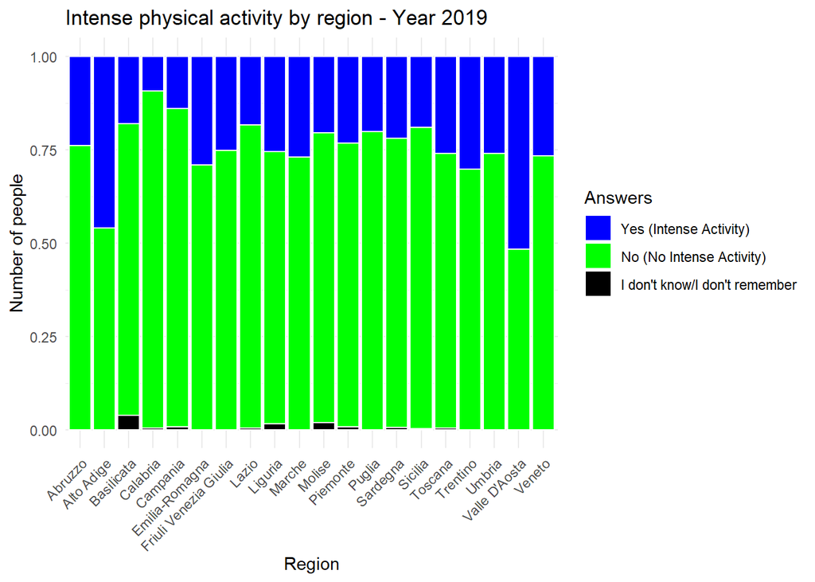

```r
# Normalized stacked bar chart on intense physical activity in 2019
ggplot(subset(dataset_att_intens_year_reg, anno == 2019),
       aes(x = regione, fill = attivita_label)) +
  geom_bar(position = "fill", color = "white") +
  scale_fill_manual(values = c(
    "Yes (Intense Activity)" = "blue",
    "No (No Intense Activity)" = "green",
    "I don't know/I don't remember" = "black"  )) +
  labs(title = "Intense physical activity by region - Year 2019",
       x = "Region",
       y = "Number of people",
       fill = "Answers") +
  theme_minimal() +
  theme(axis.text.x = element_text(angle = 45, hjust = 1))
```

### 4.1.2 Overall percentages of Intense Physical Activity in 2009 and 2019

```r
# TOTAL PERCENTAGE INTENSE PHYSICAL ACTIVITY IN 2009
dataset_att_intens_year_reg %>% filter(anno == 2009) %>%
  count(attivita_label) %>%
  mutate(percentuale = round(100 * n / sum(n), 2))
```

```
## # A tibble: 3 × 3
##   attivita_label                    n percentuale
##   <fct>                         <int>       <dbl>
## 1 Yes (Intense Activity)         1499       20.1
## 2 No (No Intense Activity)       5938       79.6
## 3 I don't know/I don't remember    22        0.29
```

```r
# TOTAL PERCENTAGE INTENSE PHYSICAL ACTIVITY IN 2019
dataset_att_intens_year_reg %>% filter(anno == 2019) %>%
  count(attivita_label) %>%
  mutate(percentuale = round(100 * n / sum(n), 2))
```

```
## # A tibble: 3 × 3
##   attivita_label                    n percentuale
##   <fct>                         <int>       <dbl>
## 1 Yes (Intense Activity)         1430       23.4
## 2 No (No Intense Activity)       4660       76.2
## 3 I don't know/I don't remember    28        0.46
```

The results indicate that the **change in the proportion** of individuals engaging in **intense physical activity** between **2009 and 2019** is **relatively modest**, with a **slight increase of about 3 percentage points** among those reporting participation.

## 4.2 Moderate Physical Analysis

### 4.2.1 Regional distribution of Moderate Physical Activity

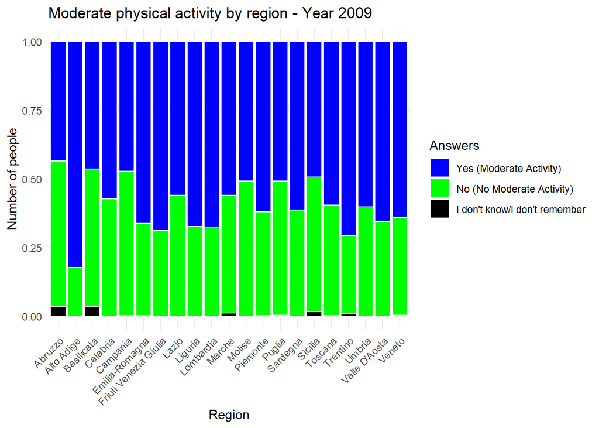

```r
# Filter for valid physical moderate activity
dataset_att_mod_year_reg = dataset_definitivo[!is.na(dataset_definitivo$s02_attiv_moder) &
                                                   dataset_definitivo$s02_attiv_moder %in% c(1, 2, -99) &
                                                   !is.na(dataset_definitivo$anno) &
                                                   !is.na(dataset_definitivo$regione),
                                                 c("s02_attiv_moder", "anno", "regione")]

# Add factor labels
dataset_att_mod_year_reg$attivita_label = factor(dataset_att_mod_year_reg$s02_attiv_moder,
                                                    levels = c(1, 2, -99),
                                                    labels = c("Yes (Moderate Activity)",
                                                               "No (No Moderate Activity)",
                                                               "I don't know/I don't remember"))

# Normalized stacked bar chart on moderate physical activity in 2009
ggplot(subset(dataset_att_mod_year_reg, anno == 2009),
       aes(x = regione, fill = attivita_label)) +
  geom_bar(position = "fill", color = "white") +
  scale_fill_manual(values = c(
    "Yes (Moderate Activity)" = "blue",
    "No (No Moderate Activity)" = "green",
    "I don't know/I don't remember" = "black"  )) +
  labs(title = "Moderate physical activity by region - Year 2009",
       x = "Region",
       y = "Number of people",
       fill = "Answers") +
  theme_minimal() +
  theme(axis.text.x = element_text(angle = 45, hjust = 1))
```

Now let’s look at **2019** for a comparison:

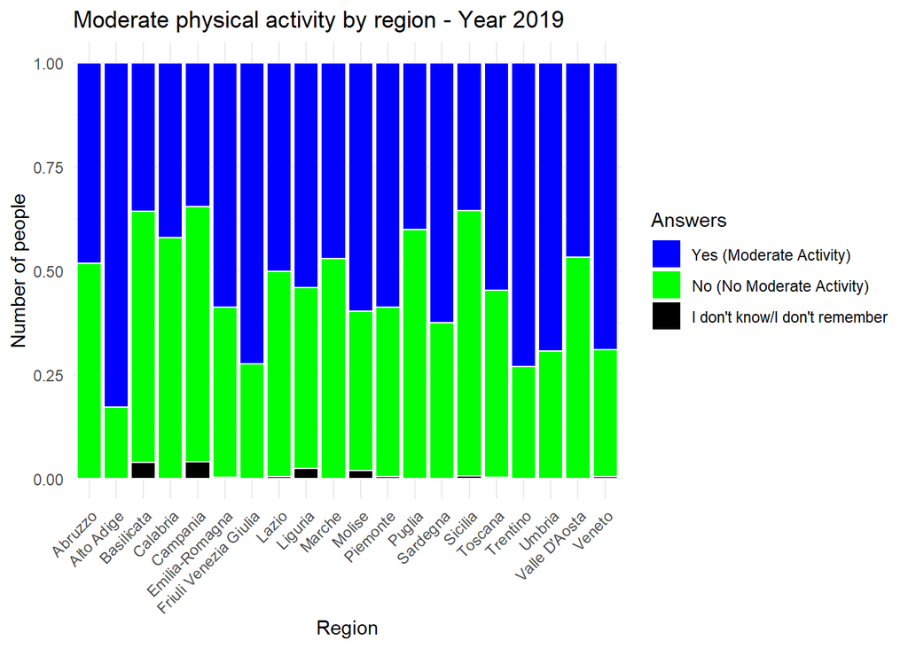

```r
# Normalized stacked bar chart on moderate physical activity in 2019
ggplot(subset(dataset_att_mod_year_reg, anno == 2019),
       aes(x = regione, fill = attivita_label)) +
  geom_bar(position = "fill", color = "white") +
  scale_fill_manual(values = c(
    "Yes (Moderate Activity)" = "blue",
    "No (No Moderate Activity)" = "green",
    "I don't know/I don't remember" = "black"  )) +
  labs(title = "Moderate physical activity by region - Year 2019",
       x = "Region",
       y = "Number of people",
       fill = "Answers") +
  theme_minimal() +
  theme(axis.text.x = element_text(angle = 45, hjust = 1))
```

Unlike the previous bar charts on **intense physical activity**, which showed **relatively low engagement**, the results for **moderate activity** indicate a **higher prevalence** among individuals. This **normalized stacked bar chart** reveals that in nearly all **Italian regions**, approximately **50% of respondents** report engaging in **moderate physical activity**. Notable exceptions include **Basilicata**, **Calabria**, **Campania**, **Puglia**, and **Sicilia**, where the **proportion is significantly lower**.

### 4.2.2 Overall percentages of Moderate Physical Activity in 2009 and 2019

```r
# TOTAL PERCENTAGE MODERATE PHYSICAL ACTIVITY IN 2009
dataset_att_mod_year_reg %>% filter(anno == 2009) %>%
  count(attivita_label) %>%
  mutate(percentuale = round(100 * n / sum(n), 2))
```

```
## # A tibble: 3 × 3
##   attivita_label                    n percentuale
##   <fct>                         <int>       <dbl>
## 1 Yes (Moderate Activity)        4468       59.9
## 2 No (No Moderate Activity)      2971       39.8
## 3 I don't know/I don't remember    25        0.33
```

```r
#TOTAL PERCENTAGE MODERATE PHYSICAL ACTIVITY IN 2019
dataset_att_mod_year_reg %>% filter(anno == 2019) %>%
  count(attivita_label) %>%
  mutate(percentuale = round(100 * n / sum(n), 2))
```

```
## # A tibble: 3 × 3
##   attivita_label                    n percentuale
##   <fct>                         <int>       <dbl>
## 1 Yes (Moderate Activity)        3302        54.0
## 2 No (No Moderate Activity)      2774        45.3
## 3 I don't know/I don't remember    43         0.7
```

Among **survey respondents**, in **2009** approximately **60%** reported engaging in **moderate physical activity**, while **40%** did not. By **2019**, the proportion of individuals reporting moderate activity **decreased by 5 percentage points**, with a corresponding **5% increase** in those **not engaging** in such activity. This suggests a **slight decline** in the practice of **moderate physical activity** over the decade.

## 4.3 Boxplot of weekly minutes of Physical Activity

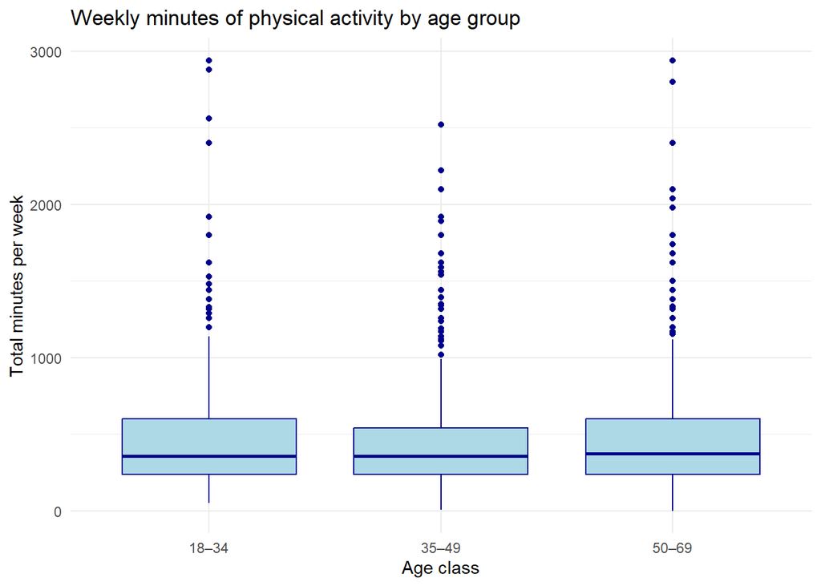

```r
# Calculating the total amount of minutes per week of moderate and intense physical activity

# Filter valid observations (exclude -99 = "I don't know/I don't remember")
dataset_durata_att_fis = dataset_definitivo %>%
  filter(s02_tlib_attiv_inte_gg >= 0,
         s02_tlib_attiv_inte_min >= 0,
         s02_attiv_moder_gg >= 0,
         s02_attiv_moder_min >= 0) %>%
  mutate(
    minuti_intensa = s02_tlib_attiv_inte_gg * s02_tlib_attiv_inte_min,
    minuti_moderata = s02_attiv_moder_gg * s02_attiv_moder_min,
    minuti_totali = minuti_intensa + minuti_moderata
  )

# Modify claeta3 form numeric to categorical value
dataset_durata_att_fis = dataset_durata_att_fis %>%
  mutate(claeta3 = factor(claeta3,
                          levels = c(1, 2, 3),
                          labels = c("18–34", "35–49", "50–69")))

# Create the boxplot
ggplot(dataset_durata_att_fis %>%
         filter(!is.na(claeta3), !is.na(minuti_totali)),
       aes(x = claeta3, y = minuti_totali)) +
  geom_boxplot(fill = "lightblue", color = "darkblue") +
  labs(
    title = "Weekly minutes of physical activity by age group",
    x = "Age class",
    y = "Total minutes per week"
  ) +
  theme_minimal()
```

From this boxplot, we can draw several key conclusions about weekly physical activity across age groups:  
• **Similar median activity**: The median weekly minutes of physical activity is fairly similar across all age groups (18–34, 35–49, 50–69). This suggests that, on average, people of different ages engage in a comparable amount of physical activity;  
• **High variability within groups**: All groups show a wide interquartile range (IQR) and long whiskers, indicating large variability in how much people exercise, regardless of age;  
• **Presence of outliers** in all groups: Every age group has several outliers, with some individuals reporting extremely high levels of weekly activity (over 2000 minutes = ~5 hours/day). This suggests that a small subset of each group exercises much more than the average;  
• **50–69 slightly more active**? The box for the 50–69 group seems slightly higher and wider, which might suggest that this group has a higher and more variable activity level compared to the younger groups. However, the difference is not dramatic and would need statistical testing to confirm.  
Overall conclusion: There is no drastic difference in average physical activity across age groups, but individual differences are significant within each group. Age alone doesn’t strongly predict how active someone is.